# The sample-size profile of the finalized survival constructions: naive / field / field-s / IJ two-term on nine cells

Campaign cert20 (n 500 / 1000 / 1500 at HR 1.50 / 1.75 / 1.00, effMaxSG eps 0.20, J 10, 31% prevalence); TASK_cert20_2026-09-08; transplanted from summary_e1stud.qmd

Author

Larry León

Published

September 9, 2026

Nine cells of the J = 10 design at 31% prevalence (`effMaxSG`, ε = 0.20, `harm_z1_quantile` 0.60, seeds 8316951 + sim_id, 2,000 replicates each): the **harm** cells at HR 1.50 and 1.75 for n = 500 / 1000 / 1500, and the **null** cells at HR 1.00 for the same three sample sizes. The two n = 500 harm cells are the committed `e1stud` bundles read as they stand (not re-run); the other seven are campaign `cert20`.

Constructions, on both blocks and on identical replicates: **naive** (reference, never a product), **MR (IJ two-term)**, **MR (field)**, **MR (field-s)**. The finalized reading (F-3, 2026-09-08) is the field one-sided **lower** bound on β(Ĥ), the field-s one-sided **upper** bound on β(Ĥᶜ), the IJ two-term two-sided interval, and the Bonferroni joint pair. The harm block has no field-s twin — field-s = field there by construction. Winner-only and winner-floor are excluded throughout. Bias is shown in **marginal-SD** and **error-SD** units side by side; bounds are read by location against clinically meaningful effect sizes, never as significance at the null; Wilson 95% limits everywhere. The stable-pick (high-p̂) under-correction is reported by stratum in Section 4, never hidden in an average.

# 1 Bundles

```r
library(forestsearch)
library(ggplot2)
library(kableExtra)
`%||%` <- function(a, b) if (is.null(a) || length(a) == 0 || all(is.na(a))) b else a
R <- "results/"
mk <- function(label, n, hr, arm, file) list(label = label, n = n, hr = hr, arm = arm, file = paste0(R, file))
cells <- list(
  mk("HR 1.50, n 500",  500L, 1.50, "harm", "fs_effMaxSG_fb_mr_field_m1_h150_knoise0_n500_z1q60_nb20_e1stud_combined_1_2000.rds"),
  mk("HR 1.50, n 1000",1000L, 1.50, "harm", "fs_effMaxSG_fb_mr_field_m1_h150_knoise0_n1000_z1q60_nb20_cert20_combined_1_2000.rds"),
  mk("HR 1.50, n 1500",1500L, 1.50, "harm", "fs_effMaxSG_fb_mr_field_m1_h150_knoise0_n1500_z1q60_nb20_cert20_combined_1_2000.rds"),
  mk("HR 1.75, n 500",  500L, 1.75, "harm", "fs_effMaxSG_fb_mr_field_m1_h175_knoise0_n500_z1q60_nb20_e1stud_combined_1_2000.rds"),
  mk("HR 1.75, n 1000",1000L, 1.75, "harm", "fs_effMaxSG_fb_mr_field_m1_h175_knoise0_n1000_z1q60_nb20_cert20_combined_1_2000.rds"),
  mk("HR 1.75, n 1500",1500L, 1.75, "harm", "fs_effMaxSG_fb_mr_field_m1_h175_knoise0_n1500_z1q60_nb20_cert20_combined_1_2000.rds"),
  mk("HR 1.00, n 500",  500L, 1.00, "null", "fs_effMaxSG_fb_mr_field_m1_h100_knoise0_n500_z1q60_nb20_cert20_combined_1_2000.rds"),
  mk("HR 1.00, n 1000",1000L, 1.00, "null", "fs_effMaxSG_fb_mr_field_m1_h100_knoise0_n1000_z1q60_nb20_cert20_combined_1_2000.rds"),
  mk("HR 1.00, n 1500",1500L, 1.00, "null", "fs_effMaxSG_fb_mr_field_m1_h100_knoise0_n1500_z1q60_nb20_cert20_combined_1_2000.rds"))
names(cells) <- vapply(cells, `[[`, "", "label")
present <- vapply(cells, function(cl) file.exists(cl$file), TRUE)
B <- lapply(cells[present], function(cl) readRDS(cl$file))
CL <- cells[present]
labs <- names(CL)
NN  <- vapply(CL, `[[`, 0L, "n"); HR <- vapply(CL, `[[`, 0, "hr"); ARM <- vapply(CL, `[[`, "", "arm")
harm_labs <- labs[ARM == "harm"]; null_labs <- labs[ARM == "null"]

INV <- do.call(rbind, lapply(labs, function(k) {
  b <- B[[k]]; r <- b$results; m <- b$meta
  data.frame(cell = k, n = NN[[k]], HR = HR[[k]], arm = ARM[[k]], rows = nrow(r),
             campaign = m$campaign_tag %||% NA, focus = m$sg_focus %||% NA,
             eps = m$effect_neighborhood %||% NA, J = m$er_jcuts %||% NA,
             z1q = m$harm_z1_quantile %||% NA, scale_c = m$field_scale_complement %||% NA,
             decomp = m$field_decompose %||% NA, fsver = m$forestsearch_version %||% NA,
             detected = sum(r$detected %in% 1L),
             prevalence = mean(r$n_true) / NN[[k]],
             marg_H = unname(b$truth$marg_H), marg_Hc = unname(b$truth$marg_Hc)) }))
kbl(INV, digits = 4, booktabs = TRUE, row.names = FALSE,
    caption = "The nine cells: bundle provenance, knobs as recorded in the pooled meta, detections, realized prevalence and the marginal Cox targets. Cells absent from disk are omitted from every table below.") |>
  kable_styling(font_size = 10)
```

The nine cells: bundle provenance, knobs as recorded in the pooled meta, detections, realized prevalence and the marginal Cox targets. Cells absent from disk are omitted from every table below.

| cell | n | HR | arm | rows | campaign | focus | eps | J | z1q | scale_c | decomp | fsver | detected | prevalence | marg_H | marg_Hc |
| --- | --- | --- | --- | --- | --- | --- | --- | --- | --- | --- | --- | --- | --- | --- | --- | --- |
| HR 1.50, n 500 | 500 | 1.50 | harm | 2000 | e1stud | effMaxSG | 0.2 | 10 | 0.6 | selected | TRUE | 0.3.5 | 1999 | 0.3059 | 1.4990 | 0.7206 |
| HR 1.50, n 1000 | 1000 | 1.50 | harm | 2000 | cert20 | effMaxSG | 0.2 | 10 | 0.6 | selected | TRUE | 0.3.5 | 2000 | 0.3063 | 1.4990 | 0.7206 |
| HR 1.50, n 1500 | 1500 | 1.50 | harm | 2000 | cert20 | effMaxSG | 0.2 | 10 | 0.6 | selected | TRUE | 0.3.5 | 2000 | 0.3065 | 1.4990 | 0.7206 |
| HR 1.75, n 500 | 500 | 1.75 | harm | 2000 | e1stud | effMaxSG | 0.2 | 10 | 0.6 | selected | TRUE | 0.3.5 | 1999 | 0.3059 | 1.7462 | 0.7206 |
| HR 1.75, n 1000 | 1000 | 1.75 | harm | 2000 | cert20 | effMaxSG | 0.2 | 10 | 0.6 | selected | TRUE | 0.3.5 | 2000 | 0.3063 | 1.7462 | 0.7206 |
| HR 1.75, n 1500 | 1500 | 1.75 | harm | 2000 | cert20 | effMaxSG | 0.2 | 10 | 0.6 | selected | TRUE | 0.3.5 | 2000 | 0.3065 | 1.7462 | 0.7206 |
| HR 1.00, n 500 | 500 | 1.00 | null | 2000 | cert20 | effMaxSG | 0.2 | 10 | 0.6 | selected | TRUE | 0.3.5 | 1841 | 0.3059 | 0.9999 | 0.7206 |
| HR 1.00, n 1000 | 1000 | 1.00 | null | 2000 | cert20 | effMaxSG | 0.2 | 10 | 0.6 | selected | TRUE | 0.3.5 | 1909 | 0.3063 | 0.9999 | 0.7206 |
| HR 1.00, n 1500 | 1500 | 1.00 | null | 2000 | cert20 | effMaxSG | 0.2 | 10 | 0.6 | selected | TRUE | 0.3.5 | 1918 | 0.3065 | 0.9999 | 0.7206 |

```r
missing_cells <- names(cells)[!present]
if (length(missing_cells)) cat("\nNOT ON DISK (omitted):", paste(missing_cells, collapse = "; "), "\n")
```

# 2 Standard tables: constructions on both blocks

```r
# field-s rows come from the same function on a column-substituted copy of the results
# (fld_Hc_* <- fld_Hc_*_s); the harm block has no _s twin (field-s = field there by construction).
subst_s <- function(r) { for (s in c("est2", "up1s", "lo1s", "lo2s", "hi2s", "lo_se", "hi_se", "se", "lam_mean")) r[[paste0("fld_Hc_", s)]] <- r[[paste0("fld_Hc_", s, "_s")]]; r }
err_sd <- function(r, block, est) { d <- r[r$detected %in% 1L, ]
  e <- switch(est, naive = d[[paste0("nv_", block, "_est")]], mr = d[[paste0("mr_", block, "_est")]], fld = d[[paste0("fld_", block, "_est2")]])
  ok <- is.finite(e) & is.finite(d[[paste0("betaHhat_", block)]]); sd(log(e[ok]) - log(d[[paste0("betaHhat_", block)]][ok])) }
cov_block <- function(r, block, side) {
  t1 <- fs_sim_bias_coverage(r, block = block, estimators = c("naive", "mr", "fld"), side = side)
  t1$sd_err <- vapply(as.character(t1$estimator), function(e) err_sd(r, block, e), 0)
  t1$construction <- c(naive = "naive", mr = "IJ two-term", fld = "field")[as.character(t1$estimator)]
  if (block == "Hc") { rs <- subst_s(r); t2 <- fs_sim_bias_coverage(rs, block = "Hc", estimators = "fld", side = side)
    t2$sd_err <- err_sd(rs, "Hc", "fld"); t2$construction <- "field-s"; t1 <- rbind(t1, t2) }
  t1$se_over_sd_err <- t1$se_mean / t1$sd_err
  t1$b_err <- t1$bias_log / t1$sd_err
  t1 }
COV <- do.call(rbind, lapply(labs, function(k) { r <- B[[k]]$results
  # NOTE: cov_block() already returns an `n` column (the replicate count), so the
  # cell's sample size is carried as `n_sample` -- a second `n` would silently
  # shadow it in every downstream selection and in fs_plot_bias_coverage().
  rbind(cbind(cell = k, n_sample = NN[[k]], hr_cell = HR[[k]], arm = ARM[[k]], block = "Hhat (lower)",  cov_block(r, "H",  "lower")),
        cbind(cell = k, n_sample = NN[[k]], hr_cell = HR[[k]], arm = ARM[[k]], block = "Hhat^c (upper)", cov_block(r, "Hc", "upper"))) }))
COV$construction <- factor(COV$construction, levels = c("naive", "field", "field-s", "IJ two-term"))
COV <- COV[order(match(COV$cell, labs), COV$block, COV$construction), ]
kbl(COV[, c("cell", "block", "construction", "n_sample", "n", "bias_log", "sd_emp", "sd_err", "b", "b_err", "se_mean", "r", "se_over_sd_err", "cov1", "cov1_wilson_lo", "cov1_wilson_hi", "cov2", "cov1_ref")],
    digits = 3, booktabs = TRUE, row.names = FALSE,
    caption = "Per cell and block (n_sample = the cell's trial size, n = replicates entering the row): bias on the log scale; marginal SD (sd_emp, across replicates -- it carries the target's own spread) and error SD (sd_err, of the de-biased error) side by side; b = bias / marginal SD and b_err = bias / error SD; mean SE; r = mean SE / marginal SD and SE / error SD; cov1 = one-sided 95% coverage on the exposed side (lower bound for beta(Hhat), upper for beta(Hhat^c)) with Wilson limits; cov2 = two-sided; cov1_ref = Gaussian reference. The harm block has no field-s row.") |>
  kable_styling(font_size = 9)
```

Per cell and block (n_sample = the cell's trial size, n = replicates entering the row): bias on the log scale; marginal SD (sd_emp, across replicates -- it carries the target's own spread) and error SD (sd_err, of the de-biased error) side by side; b = bias / marginal SD and b_err = bias / error SD; mean SE; r = mean SE / marginal SD and SE / error SD; cov1 = one-sided 95% coverage on the exposed side (lower bound for beta(Hhat), upper for beta(Hhat^c)) with Wilson limits; cov2 = two-sided; cov1_ref = Gaussian reference. The harm block has no field-s row.

| cell | block | construction | n_sample | n | bias_log | sd_emp | sd_err | b | b_err | se_mean | r | se_over_sd_err | cov1 | cov1_wilson_lo | cov1_wilson_hi | cov2 | cov1_ref |
| --- | --- | --- | --- | --- | --- | --- | --- | --- | --- | --- | --- | --- | --- | --- | --- | --- | --- |
| HR 1.50, n 500 | Hhat (lower) | naive | 500 | 1999 | 0.430 | 0.238 | 0.281 | 1.809 | 1.530 | 0.250 | 1.049 | 0.887 | 0.484 | 0.462 | 0.506 | 0.619 | 0.467 |
| HR 1.50, n 500 | Hhat (lower) | field | 500 | 1999 | -0.056 | 0.299 | 0.314 | -0.185 | -0.177 | 0.324 | 1.081 | 1.029 | 0.974 | 0.967 | 0.981 | 0.925 | 0.975 |
| HR 1.50, n 500 | Hhat (lower) | IJ two-term | 500 | 1999 | -0.003 | 0.279 | 0.303 | -0.011 | -0.010 | 0.360 | 1.289 | 1.186 | 0.985 | 0.979 | 0.990 | 0.981 | 0.983 |
| HR 1.50, n 500 | Hhat^c (upper) | naive | 500 | 1999 | -0.123 | 0.156 | 0.143 | -0.789 | -0.862 | 0.143 | 0.912 | 0.997 | 0.781 | 0.762 | 0.798 | 0.849 | 0.762 |
| HR 1.50, n 500 | Hhat^c (upper) | field | 500 | 1999 | -0.031 | 0.159 | 0.147 | -0.193 | -0.209 | 0.135 | 0.852 | 0.923 | 0.897 | 0.883 | 0.910 | 0.921 | 0.886 |
| HR 1.50, n 500 | Hhat^c (upper) | field-s | 500 | 1999 | -0.031 | 0.159 | 0.147 | -0.194 | -0.210 | 0.142 | 0.896 | 0.970 | 0.912 | 0.899 | 0.924 | 0.938 | 0.900 |
| HR 1.50, n 500 | Hhat^c (upper) | IJ two-term | 500 | 1999 | -0.044 | 0.157 | 0.145 | -0.282 | -0.307 | 0.257 | 1.636 | 1.776 | 0.995 | 0.991 | 0.997 | 1.000 | 0.992 |
| HR 1.50, n 1000 | Hhat (lower) | naive | 1000 | 2000 | 0.229 | 0.196 | 0.234 | 1.171 | 0.982 | 0.171 | 0.875 | 0.734 | 0.643 | 0.622 | 0.664 | 0.750 | 0.606 |
| HR 1.50, n 1000 | Hhat (lower) | field | 1000 | 2000 | -0.044 | 0.228 | 0.246 | -0.194 | -0.180 | 0.233 | 1.021 | 0.945 | 0.959 | 0.949 | 0.966 | 0.917 | 0.969 |
| HR 1.50, n 1000 | Hhat (lower) | IJ two-term | 1000 | 2000 | -0.035 | 0.218 | 0.242 | -0.160 | -0.144 | 0.263 | 1.206 | 1.084 | 0.985 | 0.978 | 0.989 | 0.971 | 0.984 |
| HR 1.50, n 1000 | Hhat^c (upper) | naive | 1000 | 2000 | -0.064 | 0.120 | 0.100 | -0.537 | -0.642 | 0.102 | 0.854 | 1.021 | 0.852 | 0.836 | 0.867 | 0.909 | 0.807 |
| HR 1.50, n 1000 | Hhat^c (upper) | field | 1000 | 2000 | -0.006 | 0.123 | 0.105 | -0.051 | -0.060 | 0.097 | 0.791 | 0.928 | 0.930 | 0.918 | 0.940 | 0.927 | 0.894 |
| HR 1.50, n 1000 | Hhat^c (upper) | field-s | 1000 | 2000 | -0.007 | 0.123 | 0.105 | -0.055 | -0.065 | 0.103 | 0.832 | 0.976 | 0.942 | 0.931 | 0.951 | 0.941 | 0.906 |
| HR 1.50, n 1000 | Hhat^c (upper) | IJ two-term | 1000 | 2000 | -0.013 | 0.121 | 0.103 | -0.110 | -0.129 | 0.186 | 1.531 | 1.801 | 0.999 | 0.996 | 0.999 | 1.000 | 0.992 |
| HR 1.50, n 1500 | Hhat (lower) | naive | 1500 | 2000 | 0.110 | 0.160 | 0.173 | 0.692 | 0.640 | 0.126 | 0.787 | 0.728 | 0.795 | 0.777 | 0.812 | 0.852 | 0.727 |
| HR 1.50, n 1500 | Hhat (lower) | field | 1500 | 2000 | -0.040 | 0.175 | 0.180 | -0.228 | -0.222 | 0.179 | 1.018 | 0.991 | 0.962 | 0.952 | 0.969 | 0.920 | 0.971 |
| HR 1.50, n 1500 | Hhat (lower) | IJ two-term | 1500 | 2000 | -0.052 | 0.171 | 0.178 | -0.302 | -0.291 | 0.209 | 1.221 | 1.174 | 0.992 | 0.986 | 0.995 | 0.976 | 0.990 |
| HR 1.50, n 1500 | Hhat^c (upper) | naive | 1500 | 2000 | -0.045 | 0.103 | 0.084 | -0.435 | -0.530 | 0.087 | 0.843 | 1.027 | 0.880 | 0.865 | 0.894 | 0.936 | 0.829 |
| HR 1.50, n 1500 | Hhat^c (upper) | field | 1500 | 2000 | -0.005 | 0.107 | 0.089 | -0.046 | -0.055 | 0.083 | 0.772 | 0.929 | 0.939 | 0.928 | 0.949 | 0.926 | 0.889 |
| HR 1.50, n 1500 | Hhat^c (upper) | field-s | 1500 | 2000 | -0.006 | 0.107 | 0.089 | -0.053 | -0.064 | 0.088 | 0.816 | 0.983 | 0.947 | 0.936 | 0.956 | 0.944 | 0.901 |
| HR 1.50, n 1500 | Hhat^c (upper) | IJ two-term | 1500 | 2000 | -0.007 | 0.105 | 0.087 | -0.071 | -0.085 | 0.158 | 1.498 | 1.803 | 0.999 | 0.996 | 1.000 | 1.000 | 0.992 |
| HR 1.75, n 500 | Hhat (lower) | naive | 500 | 1999 | 0.365 | 0.246 | 0.294 | 1.481 | 1.241 | 0.243 | 0.985 | 0.825 | 0.573 | 0.551 | 0.595 | 0.694 | 0.555 |
| HR 1.75, n 500 | Hhat (lower) | field | 500 | 1999 | -0.078 | 0.312 | 0.329 | -0.251 | -0.238 | 0.323 | 1.035 | 0.983 | 0.970 | 0.962 | 0.977 | 0.911 | 0.975 |
| HR 1.75, n 500 | Hhat (lower) | IJ two-term | 500 | 1999 | -0.037 | 0.291 | 0.317 | -0.129 | -0.118 | 0.356 | 1.227 | 1.125 | 0.985 | 0.979 | 0.989 | 0.972 | 0.984 |
| HR 1.75, n 500 | Hhat^c (upper) | naive | 500 | 1999 | -0.102 | 0.162 | 0.144 | -0.631 | -0.708 | 0.143 | 0.884 | 0.991 | 0.826 | 0.809 | 0.842 | 0.880 | 0.795 |
| HR 1.75, n 500 | Hhat^c (upper) | field | 500 | 1999 | -0.019 | 0.165 | 0.149 | -0.116 | -0.128 | 0.136 | 0.822 | 0.911 | 0.912 | 0.899 | 0.924 | 0.918 | 0.892 |
| HR 1.75, n 500 | Hhat^c (upper) | field-s | 500 | 1999 | -0.019 | 0.165 | 0.149 | -0.117 | -0.130 | 0.143 | 0.868 | 0.961 | 0.919 | 0.907 | 0.931 | 0.933 | 0.905 |
| HR 1.75, n 500 | Hhat^c (upper) | IJ two-term | 500 | 1999 | -0.030 | 0.163 | 0.147 | -0.183 | -0.204 | 0.258 | 1.586 | 1.761 | 0.995 | 0.991 | 0.998 | 0.999 | 0.992 |
| HR 1.75, n 1000 | Hhat (lower) | naive | 1000 | 2000 | 0.179 | 0.198 | 0.231 | 0.901 | 0.774 | 0.165 | 0.832 | 0.715 | 0.737 | 0.717 | 0.756 | 0.811 | 0.680 |
| HR 1.75, n 1000 | Hhat (lower) | field | 1000 | 2000 | -0.050 | 0.228 | 0.242 | -0.220 | -0.207 | 0.231 | 1.013 | 0.953 | 0.953 | 0.942 | 0.961 | 0.915 | 0.970 |
| HR 1.75, n 1000 | Hhat (lower) | IJ two-term | 1000 | 2000 | -0.052 | 0.220 | 0.240 | -0.235 | -0.216 | 0.262 | 1.190 | 1.092 | 0.988 | 0.982 | 0.992 | 0.974 | 0.986 |
| HR 1.75, n 1000 | Hhat^c (upper) | naive | 1000 | 2000 | -0.049 | 0.128 | 0.102 | -0.385 | -0.482 | 0.103 | 0.807 | 1.009 | 0.881 | 0.866 | 0.894 | 0.926 | 0.827 |
| HR 1.75, n 1000 | Hhat^c (upper) | field | 1000 | 2000 | -0.002 | 0.131 | 0.107 | -0.014 | -0.018 | 0.098 | 0.749 | 0.915 | 0.936 | 0.924 | 0.946 | 0.923 | 0.888 |
| HR 1.75, n 1000 | Hhat^c (upper) | field-s | 1000 | 2000 | -0.002 | 0.131 | 0.107 | -0.019 | -0.023 | 0.104 | 0.790 | 0.966 | 0.942 | 0.931 | 0.951 | 0.939 | 0.900 |
| HR 1.75, n 1000 | Hhat^c (upper) | IJ two-term | 1000 | 2000 | -0.006 | 0.129 | 0.105 | -0.044 | -0.054 | 0.188 | 1.455 | 1.784 | 0.999 | 0.996 | 1.000 | 1.000 | 0.991 |
| HR 1.75, n 1500 | Hhat (lower) | naive | 1500 | 2000 | 0.081 | 0.158 | 0.167 | 0.510 | 0.483 | 0.123 | 0.775 | 0.734 | 0.831 | 0.814 | 0.847 | 0.877 | 0.778 |
| HR 1.75, n 1500 | Hhat (lower) | field | 1500 | 2000 | -0.036 | 0.169 | 0.174 | -0.214 | -0.208 | 0.174 | 1.028 | 1.003 | 0.961 | 0.952 | 0.969 | 0.930 | 0.972 |
| HR 1.75, n 1500 | Hhat (lower) | IJ two-term | 1500 | 2000 | -0.054 | 0.168 | 0.173 | -0.319 | -0.310 | 0.211 | 1.256 | 1.221 | 0.992 | 0.986 | 0.995 | 0.981 | 0.991 |
| HR 1.75, n 1500 | Hhat^c (upper) | naive | 1500 | 2000 | -0.034 | 0.107 | 0.084 | -0.321 | -0.406 | 0.087 | 0.812 | 1.028 | 0.907 | 0.894 | 0.919 | 0.942 | 0.845 |
| HR 1.75, n 1500 | Hhat^c (upper) | field | 1500 | 2000 | -0.005 | 0.110 | 0.088 | -0.042 | -0.053 | 0.083 | 0.756 | 0.947 | 0.941 | 0.930 | 0.951 | 0.930 | 0.885 |
| HR 1.75, n 1500 | Hhat^c (upper) | field-s | 1500 | 2000 | -0.005 | 0.111 | 0.088 | -0.049 | -0.062 | 0.088 | 0.795 | 0.996 | 0.946 | 0.935 | 0.955 | 0.946 | 0.896 |
| HR 1.75, n 1500 | Hhat^c (upper) | IJ two-term | 1500 | 2000 | -0.005 | 0.109 | 0.087 | -0.042 | -0.053 | 0.160 | 1.469 | 1.838 | 0.999 | 0.996 | 0.999 | 1.000 | 0.991 |
| HR 1.00, n 500 | Hhat (lower) | naive | 500 | 1841 | 0.610 | 0.192 | 0.217 | 3.172 | 2.812 | 0.272 | 1.412 | 1.252 | 0.169 | 0.153 | 0.187 | 0.349 | 0.198 |
| HR 1.00, n 500 | Hhat (lower) | field | 500 | 1841 | 0.028 | 0.245 | 0.259 | 0.115 | 0.109 | 0.325 | 1.328 | 1.256 | 0.973 | 0.965 | 0.980 | 0.986 | 0.981 |
| HR 1.00, n 500 | Hhat (lower) | IJ two-term | 500 | 1841 | 0.107 | 0.227 | 0.245 | 0.470 | 0.437 | 0.372 | 1.635 | 1.518 | 0.981 | 0.974 | 0.986 | 0.995 | 0.987 |
| HR 1.00, n 500 | Hhat^c (upper) | naive | 500 | 1841 | -0.148 | 0.138 | 0.134 | -1.074 | -1.107 | 0.143 | 1.032 | 1.064 | 0.746 | 0.725 | 0.765 | 0.837 | 0.734 |
| HR 1.00, n 500 | Hhat^c (upper) | field | 500 | 1841 | -0.041 | 0.142 | 0.139 | -0.286 | -0.292 | 0.136 | 0.960 | 0.983 | 0.904 | 0.890 | 0.917 | 0.936 | 0.902 |
| HR 1.00, n 500 | Hhat^c (upper) | field-s | 500 | 1841 | -0.041 | 0.142 | 0.138 | -0.287 | -0.294 | 0.141 | 0.998 | 1.022 | 0.911 | 0.898 | 0.924 | 0.948 | 0.912 |
| HR 1.00, n 500 | Hhat^c (upper) | IJ two-term | 500 | 1841 | -0.059 | 0.140 | 0.136 | -0.423 | -0.434 | 0.255 | 1.824 | 1.871 | 0.995 | 0.991 | 0.997 | 0.999 | 0.995 |
| HR 1.00, n 1000 | Hhat (lower) | naive | 1000 | 1909 | 0.406 | 0.170 | 0.203 | 2.390 | 1.996 | 0.193 | 1.136 | 0.949 | 0.280 | 0.261 | 0.301 | 0.449 | 0.301 |
| HR 1.00, n 1000 | Hhat (lower) | field | 1000 | 1909 | 0.015 | 0.194 | 0.216 | 0.078 | 0.070 | 0.232 | 1.192 | 1.073 | 0.956 | 0.946 | 0.964 | 0.965 | 0.970 |
| HR 1.00, n 1000 | Hhat (lower) | IJ two-term | 1000 | 1909 | 0.058 | 0.185 | 0.211 | 0.311 | 0.273 | 0.268 | 1.446 | 1.269 | 0.983 | 0.976 | 0.988 | 0.995 | 0.981 |
| HR 1.00, n 1000 | Hhat^c (upper) | naive | 1000 | 1909 | -0.101 | 0.102 | 0.096 | -0.993 | -1.047 | 0.102 | 1.000 | 1.055 | 0.765 | 0.745 | 0.783 | 0.852 | 0.743 |
| HR 1.00, n 1000 | Hhat^c (upper) | field | 1000 | 1909 | -0.021 | 0.103 | 0.099 | -0.200 | -0.209 | 0.097 | 0.933 | 0.973 | 0.918 | 0.905 | 0.930 | 0.935 | 0.909 |
| HR 1.00, n 1000 | Hhat^c (upper) | field-s | 1000 | 1909 | -0.021 | 0.103 | 0.099 | -0.203 | -0.212 | 0.100 | 0.973 | 1.013 | 0.928 | 0.915 | 0.938 | 0.949 | 0.919 |
| HR 1.00, n 1000 | Hhat^c (upper) | IJ two-term | 1000 | 1909 | -0.035 | 0.102 | 0.098 | -0.344 | -0.359 | 0.182 | 1.778 | 1.858 | 0.996 | 0.992 | 0.998 | 1.000 | 0.995 |
| HR 1.00, n 1500 | Hhat (lower) | naive | 1500 | 1918 | 0.261 | 0.132 | 0.161 | 1.981 | 1.627 | 0.142 | 1.077 | 0.885 | 0.449 | 0.427 | 0.471 | 0.586 | 0.417 |
| HR 1.00, n 1500 | Hhat (lower) | field | 1500 | 1918 | -0.011 | 0.147 | 0.163 | -0.075 | -0.067 | 0.179 | 1.222 | 1.096 | 0.967 | 0.958 | 0.974 | 0.964 | 0.981 |
| HR 1.00, n 1500 | Hhat (lower) | IJ two-term | 1500 | 1918 | 0.010 | 0.141 | 0.162 | 0.072 | 0.063 | 0.206 | 1.466 | 1.273 | 0.991 | 0.985 | 0.994 | 0.996 | 0.990 |
| HR 1.00, n 1500 | Hhat^c (upper) | naive | 1500 | 1918 | -0.088 | 0.084 | 0.080 | -1.051 | -1.106 | 0.086 | 1.028 | 1.081 | 0.754 | 0.734 | 0.773 | 0.845 | 0.739 |
| HR 1.00, n 1500 | Hhat^c (upper) | field | 1500 | 1918 | -0.019 | 0.086 | 0.082 | -0.216 | -0.226 | 0.081 | 0.935 | 0.980 | 0.913 | 0.900 | 0.925 | 0.944 | 0.907 |
| HR 1.00, n 1500 | Hhat^c (upper) | field-s | 1500 | 1918 | -0.019 | 0.086 | 0.082 | -0.220 | -0.231 | 0.085 | 0.988 | 1.036 | 0.927 | 0.914 | 0.938 | 0.956 | 0.920 |
| HR 1.00, n 1500 | Hhat^c (upper) | IJ two-term | 1500 | 1918 | -0.031 | 0.085 | 0.081 | -0.366 | -0.383 | 0.152 | 1.789 | 1.874 | 0.999 | 0.997 | 1.000 | 1.000 | 0.995 |

```r
ACR <- do.call(rbind, lapply(split(COV, list(COV$block, COV$construction, COV$arm), drop = TRUE), function(d)
  data.frame(arm = d$arm[1], block = d$block[1], construction = d$construction[1], cells = nrow(d),
             cov1_min = min(d$cov1), cov1_mean = mean(d$cov1), cov1_max = max(d$cov1),
             cov2_mean = mean(d$cov2), b_mean = mean(d$b), r_mean = mean(d$r),
             se_over_sd_err_mean = mean(d$se_over_sd_err))))
ACR <- ACR[order(ACR$arm, ACR$block, ACR$construction), ]
kbl(ACR, digits = 3, booktabs = TRUE, row.names = FALSE,
    caption = "Across cells, split by arm (harm cells / null cells): range and mean of the one-sided coverage, mean two-sided coverage, mean b and r.") |> kable_styling(font_size = 10)
```

Across cells, split by arm (harm cells / null cells): range and mean of the one-sided coverage, mean two-sided coverage, mean b and r.

| arm | block | construction | cells | cov1_min | cov1_mean | cov1_max | cov2_mean | b_mean | r_mean | se_over_sd_err_mean |
| --- | --- | --- | --- | --- | --- | --- | --- | --- | --- | --- |
| harm | Hhat (lower) | naive | 6 | 0.484 | 0.677 | 0.831 | 0.767 | 1.094 | 0.884 | 0.771 |
| harm | Hhat (lower) | field | 6 | 0.953 | 0.963 | 0.974 | 0.920 | -0.215 | 1.033 | 0.984 |
| harm | Hhat (lower) | IJ two-term | 6 | 0.985 | 0.988 | 0.992 | 0.976 | -0.193 | 1.231 | 1.147 |
| harm | Hhat^c (upper) | naive | 6 | 0.781 | 0.855 | 0.907 | 0.907 | -0.516 | 0.852 | 1.012 |
| harm | Hhat^c (upper) | field | 6 | 0.897 | 0.926 | 0.941 | 0.924 | -0.077 | 0.790 | 0.925 |
| harm | Hhat^c (upper) | field-s | 6 | 0.912 | 0.935 | 0.947 | 0.940 | -0.081 | 0.833 | 0.975 |
| harm | Hhat^c (upper) | IJ two-term | 6 | 0.995 | 0.998 | 0.999 | 1.000 | -0.122 | 1.529 | 1.794 |
| null | Hhat (lower) | naive | 3 | 0.169 | 0.300 | 0.449 | 0.461 | 2.514 | 1.209 | 1.029 |
| null | Hhat (lower) | field | 3 | 0.956 | 0.965 | 0.973 | 0.972 | 0.040 | 1.247 | 1.142 |
| null | Hhat (lower) | IJ two-term | 3 | 0.981 | 0.985 | 0.991 | 0.995 | 0.284 | 1.516 | 1.353 |
| null | Hhat^c (upper) | naive | 3 | 0.746 | 0.755 | 0.765 | 0.845 | -1.039 | 1.020 | 1.067 |
| null | Hhat^c (upper) | field | 3 | 0.904 | 0.912 | 0.918 | 0.938 | -0.234 | 0.943 | 0.979 |
| null | Hhat^c (upper) | field-s | 3 | 0.911 | 0.922 | 0.928 | 0.951 | -0.237 | 0.986 | 1.023 |
| null | Hhat^c (upper) | IJ two-term | 3 | 0.995 | 0.997 | 0.999 | 1.000 | -0.378 | 1.797 | 1.868 |

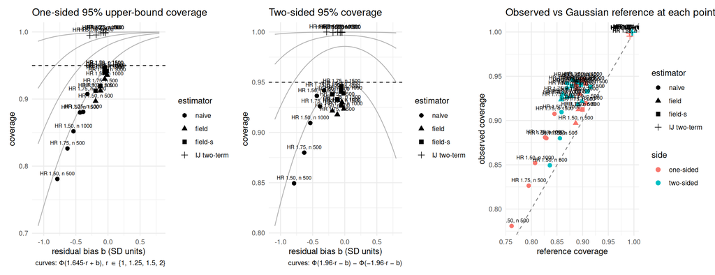

```r
tabC <- COV[COV$block == "Hhat^c (upper)" & COV$arm == "harm", ]
tabC$estimator <- tabC$construction
tabC <- tabC[, setdiff(names(tabC), c("n_sample", "hr_cell", "arm", "block", "sd_err", "se_over_sd_err", "b_err", "construction"))]
fs_plot_bias_coverage(tabC, curves = c(1, 1.25, 1.5, 2), side = "upper")
```

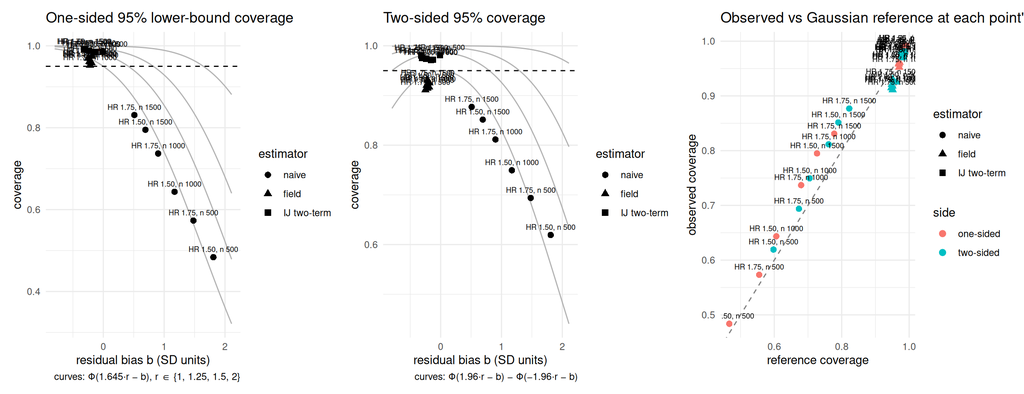

```r
tabH <- COV[COV$block == "Hhat (lower)" & COV$arm == "harm", ]
tabH$estimator <- tabH$construction
tabH <- tabH[, setdiff(names(tabH), c("n_sample", "hr_cell", "arm", "block", "sd_err", "se_over_sd_err", "b_err", "construction"))]
fs_plot_bias_coverage(tabH, curves = c(1, 1.25, 1.5, 2), side = "lower")
```

# 3 Coverage versus n

```r
wil <- function(p, n, z = stats::qnorm(0.975)) {
  ctr <- (p + z^2 / (2 * n)) / (1 + z^2 / n)
  hw  <- z * sqrt(p * (1 - p) / n + z^2 / (4 * n^2)) / (1 + z^2 / n)
  c(ctr - hw, ctr + hw) }
z95 <- stats::qnorm(0.95); z975 <- stats::qnorm(0.975)
covs_cell <- function(k) {
  r <- B[[k]]$results
  d <- r[r$detected %in% 1L & is.finite(r$betaHhat_H) & is.finite(r$betaHhat_Hc) &
         is.finite(r$fld_H_lo1s) & is.finite(r$fld_Hc_up1s_s), , drop = FALSE]
  cH  <- mean(d$betaHhat_H  >= d$fld_H_lo1s)                       # harm field one-sided lower
  cC  <- mean(d$betaHhat_Hc <= d$fld_Hc_up1s_s)                    # complement field-s one-sided upper
  cCf <- mean(d$betaHhat_Hc <= d$fld_Hc_up1s)                      # complement field (unscaled), beside
  ij_H  <- mean(d$betaHhat_H  >= d$mr_H_lo  & d$betaHhat_H  <= d$mr_H_hi)
  ij_Hc <- mean(d$betaHhat_Hc >= d$mr_Hc_lo & d$betaHhat_Hc <= d$mr_Hc_hi)
  jt  <- mean(d$betaHhat_H >= d$fld_joint_bonf_loH & d$betaHhat_Hc <= d$fld_joint_bonf_upHc)
  jts <- mean(d$betaHhat_H >= d$fld_joint_s_bonf_loH & d$betaHhat_Hc <= d$fld_joint_s_bonf_upHc)
  g <- function(p) { w <- wil(p, nrow(d)); c(p, w) }
  data.frame(cell = k, n = NN[[k]], HR = HR[[k]], arm = ARM[[k]], n_eval = nrow(d),
             harm_field = cH, harm_field_lo = g(cH)[2], harm_field_hi = g(cH)[3],
             comp_field_s = cC, comp_field_s_lo = g(cC)[2], comp_field_s_hi = g(cC)[3],
             comp_field = cCf, comp_field_lo = g(cCf)[2], comp_field_hi = g(cCf)[3],
             ij2_H = ij_H, ij2_H_lo = g(ij_H)[2], ij2_H_hi = g(ij_H)[3],
             ij2_Hc = ij_Hc, ij2_Hc_lo = g(ij_Hc)[2], ij2_Hc_hi = g(ij_Hc)[3],
             joint_bonf = jt, joint_bonf_lo = g(jt)[2], joint_bonf_hi = g(jt)[3],
             joint_s_bonf = jts, joint_s_bonf_lo = g(jts)[2], joint_s_bonf_hi = g(jts)[3]) }
VSN <- do.call(rbind, lapply(labs, covs_cell))
VSN <- VSN[order(VSN$arm, VSN$HR, VSN$n), ]
```

## 3.1 Harm block: the field one-sided lower bound on β(Ĥ), and the IJ two-sided interval

```r
kbl(VSN[VSN$arm == "harm", c("cell", "n", "HR", "n_eval", "harm_field", "harm_field_lo", "harm_field_hi", "ij2_H", "ij2_H_lo", "ij2_H_hi")],
    digits = 4, booktabs = TRUE, row.names = FALSE,
    caption = "Harm cells: one-sided 95% lower coverage of beta(Hhat) by the field bound and two-sided coverage by the IJ two-term interval, with Wilson limits, against n at each HR.") |>
  kable_styling(font_size = 10)
```

Harm cells: one-sided 95% lower coverage of beta(Hhat) by the field bound and two-sided coverage by the IJ two-term interval, with Wilson limits, against n at each HR.

| cell | n | HR | n_eval | harm_field | harm_field_lo | harm_field_hi | ij2_H | ij2_H_lo | ij2_H_hi |
| --- | --- | --- | --- | --- | --- | --- | --- | --- | --- |
| HR 1.50, n 500 | 500 | 1.50 | 1999 | 0.9745 | 0.9666 | 0.9805 | 0.9810 | 0.9740 | 0.9861 |
| HR 1.50, n 1000 | 1000 | 1.50 | 2000 | 0.9585 | 0.9488 | 0.9664 | 0.9710 | 0.9627 | 0.9775 |
| HR 1.50, n 1500 | 1500 | 1.50 | 2000 | 0.9615 | 0.9521 | 0.9691 | 0.9755 | 0.9678 | 0.9814 |
| HR 1.75, n 500 | 500 | 1.75 | 1999 | 0.9700 | 0.9616 | 0.9766 | 0.9720 | 0.9638 | 0.9784 |
| HR 1.75, n 1000 | 1000 | 1.75 | 2000 | 0.9525 | 0.9423 | 0.9610 | 0.9740 | 0.9661 | 0.9801 |
| HR 1.75, n 1500 | 1500 | 1.75 | 2000 | 0.9610 | 0.9516 | 0.9686 | 0.9805 | 0.9735 | 0.9857 |

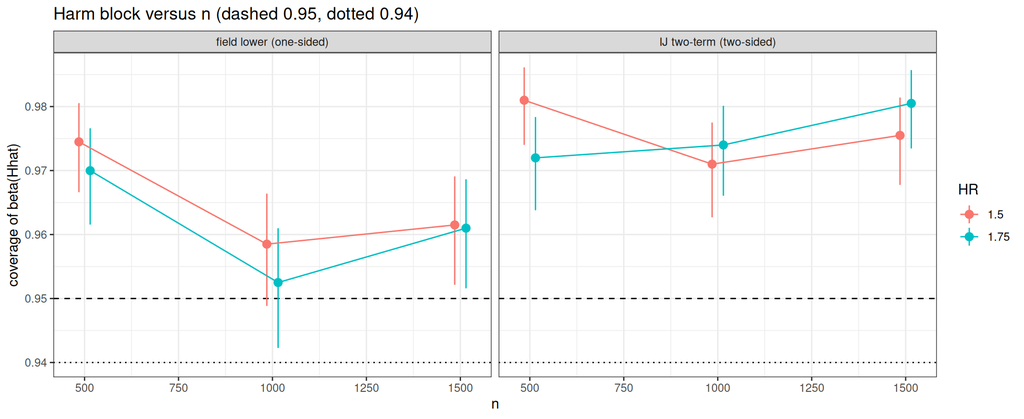

```r
ph <- VSN[VSN$arm == "harm", ]
PH <- rbind(data.frame(n = ph$n, HR = factor(ph$HR), construction = "field lower (one-sided)", cov = ph$harm_field, lo = ph$harm_field_lo, hi = ph$harm_field_hi),
            data.frame(n = ph$n, HR = factor(ph$HR), construction = "IJ two-term (two-sided)", cov = ph$ij2_H, lo = ph$ij2_H_lo, hi = ph$ij2_H_hi))
ggplot(PH, aes(n, cov, colour = HR, group = HR)) +
  geom_hline(yintercept = 0.95, linetype = 2) + geom_hline(yintercept = 0.94, linetype = 3) +
  geom_pointrange(aes(ymin = lo, ymax = hi), position = position_dodge(width = 60)) +
  geom_line(position = position_dodge(width = 60)) + facet_wrap(~ construction) +
  labs(x = "n", y = "coverage of beta(Hhat)", title = "Harm block versus n (dashed 0.95, dotted 0.94)") + theme_bw(base_size = 11)
```

## 3.2 Complement block: the field-s one-sided upper bound on β(Ĥᶜ), field beside; IJ two-sided; joint

```r
kbl(VSN[VSN$arm == "harm", c("cell", "n", "HR", "n_eval", "comp_field_s", "comp_field_s_lo", "comp_field_s_hi", "comp_field", "ij2_Hc", "ij2_Hc_lo", "ij2_Hc_hi", "joint_bonf", "joint_s_bonf", "joint_s_bonf_lo", "joint_s_bonf_hi")],
    digits = 4, booktabs = TRUE, row.names = FALSE,
    caption = "Harm cells: one-sided 95% upper coverage of beta(Hhat^c) by field-s (Wilson) with the unscaled field beside it; two-sided IJ two-term coverage; and the Bonferroni joint pair from the unscaled joint and from joint_s (Wilson on joint_s).") |>
  kable_styling(font_size = 10)
```

Harm cells: one-sided 95% upper coverage of beta(Hhat^c) by field-s (Wilson) with the unscaled field beside it; two-sided IJ two-term coverage; and the Bonferroni joint pair from the unscaled joint and from joint_s (Wilson on joint_s).

| cell | n | HR | n_eval | comp_field_s | comp_field_s_lo | comp_field_s_hi | comp_field | ij2_Hc | ij2_Hc_lo | ij2_Hc_hi | joint_bonf | joint_s_bonf | joint_s_bonf_lo | joint_s_bonf_hi |
| --- | --- | --- | --- | --- | --- | --- | --- | --- | --- | --- | --- | --- | --- | --- |
| HR 1.50, n 500 | 500 | 1.50 | 1999 | 0.9125 | 0.8993 | 0.9241 | 0.8969 | 1.0000 | 0.9981 | 1.0000 | 0.9320 | 0.9420 | 0.9308 | 0.9514 |
| HR 1.50, n 1000 | 1000 | 1.50 | 2000 | 0.9420 | 0.9309 | 0.9514 | 0.9300 | 1.0000 | 0.9981 | 1.0000 | 0.9460 | 0.9500 | 0.9396 | 0.9587 |
| HR 1.50, n 1500 | 1500 | 1.50 | 2000 | 0.9465 | 0.9358 | 0.9555 | 0.9390 | 0.9995 | 0.9972 | 0.9999 | 0.9440 | 0.9505 | 0.9401 | 0.9592 |
| HR 1.75, n 500 | 500 | 1.75 | 1999 | 0.9195 | 0.9067 | 0.9306 | 0.9125 | 0.9995 | 0.9972 | 0.9999 | 0.9335 | 0.9395 | 0.9281 | 0.9491 |
| HR 1.75, n 1000 | 1000 | 1.75 | 2000 | 0.9420 | 0.9309 | 0.9514 | 0.9360 | 1.0000 | 0.9981 | 1.0000 | 0.9445 | 0.9485 | 0.9379 | 0.9574 |
| HR 1.75, n 1500 | 1500 | 1.75 | 2000 | 0.9460 | 0.9352 | 0.9551 | 0.9410 | 0.9995 | 0.9972 | 0.9999 | 0.9425 | 0.9490 | 0.9385 | 0.9578 |

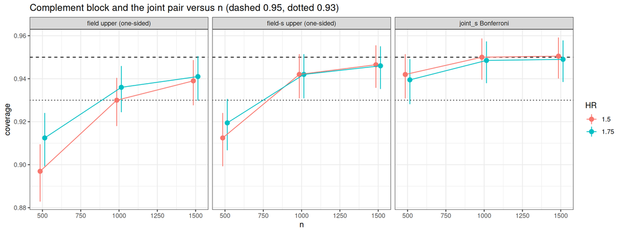

```r
PC <- rbind(data.frame(n = ph$n, HR = factor(ph$HR), construction = "field-s upper (one-sided)", cov = ph$comp_field_s, lo = ph$comp_field_s_lo, hi = ph$comp_field_s_hi),
            data.frame(n = ph$n, HR = factor(ph$HR), construction = "field upper (one-sided)",   cov = ph$comp_field,   lo = ph$comp_field_lo,   hi = ph$comp_field_hi),
            data.frame(n = ph$n, HR = factor(ph$HR), construction = "joint_s Bonferroni",        cov = ph$joint_s_bonf, lo = ph$joint_s_bonf_lo, hi = ph$joint_s_bonf_hi))
ggplot(PC, aes(n, cov, colour = HR, group = HR)) +
  geom_hline(yintercept = 0.95, linetype = 2) + geom_hline(yintercept = 0.93, linetype = 3) +
  geom_pointrange(aes(ymin = lo, ymax = hi), position = position_dodge(width = 60)) +
  geom_line(position = position_dodge(width = 60)) + facet_wrap(~ construction) +
  labs(x = "n", y = "coverage", title = "Complement block and the joint pair versus n (dashed 0.95, dotted 0.93)") + theme_bw(base_size = 11)
```

# 4 By p̂ tertile, every cell, both blocks

The stable-pick caveat versus n: does the high-p̂ shortfall shrink as n grows? Gaussian-implied beside observed, computed from each stratum’s own numbers exactly as in `summary_complement_variance.qmd` §A5 / §A6 — for the complement, $b = \bar e_{f,s}/\mathrm{SD}(e_{f,s})$, $r = \overline{\texttt{se\_field\_s}}/\mathrm{SD}(e_{f,s})$ and $\Phi(z_{0.95} r + b)$; for the harm block, $b = \bar e_{f,H}/\mathrm{SD}(e_{f,H})$, $r = \overline{\texttt{fld\_H\_se}}/\mathrm{SD}(e_{f,H})$ and $\Phi(z_{0.95} r - b)$. The SD is the **error** SD throughout, not the marginal SD of Section 2.

```r
prep <- function(r) {
  need <- c("betaHhat_H", "betaHhat_Hc", "fld_H_est2", "fld_H_lo1s", "fld_H_se", "fld_H_lam_mean",
            "fld_Hc_est2", "fld_Hc_est2_s", "fld_Hc_up1s", "fld_Hc_up1s_s", "fld_Hc_se_s",
            "fld_Hc_scale_ratio", "p_hat_H", "mr_H_est", "mr_H_se_ij", "mr_Hc_est", "mr_Hc_se_ij",
            "nv_H_se", "nv_Hc_se", "n_harm", "n_true")
  d <- r[r$detected %in% 1L, , drop = FALSE]
  d <- d[Reduce(`&`, lapply(need, function(cn) is.finite(d[[cn]]))), , drop = FALSE]
  d$ef_H  <- log(d$fld_H_est2)    - log(d$betaHhat_H)
  d$ef_s  <- log(d$fld_Hc_est2_s) - log(d$betaHhat_Hc)
  d$ef    <- log(d$fld_Hc_est2)   - log(d$betaHhat_Hc)
  d$ratio_H <- d$n_harm / d$n_true
  d }
strat_row <- function(d, cell, stratum) {
  bH <- mean(d$ef_H) / sd(d$ef_H); rH <- mean(d$fld_H_se) / sd(d$ef_H)
  bC <- mean(d$ef_s) / sd(d$ef_s); rC <- mean(d$fld_Hc_se_s) / sd(d$ef_s)
  cfH <- mean(d$betaHhat_H  >= d$fld_H_lo1s);    wH <- wil(cfH, nrow(d))
  cfC <- mean(d$betaHhat_Hc <= d$fld_Hc_up1s_s); wC <- wil(cfC, nrow(d))
  cfCu <- mean(d$betaHhat_Hc <= d$fld_Hc_up1s)
  data.frame(cell = cell, stratum = stratum, n = nrow(d), p_hat_mean = mean(d$p_hat_H),
             Hhat_over_H = mean(d$ratio_H), rho_c = mean(d$fld_Hc_scale_ratio),
             mean_ef_H = mean(d$ef_H), SD_ef_H = sd(d$ef_H), b_H = bH, r_H = rH,
             cov_field_H = cfH, wH_lo = wH[1], wH_hi = wH[2], gauss_H = stats::pnorm(z95 * rH - bH),
             mean_ef_s = mean(d$ef_s), SD_ef_s = sd(d$ef_s), b_C = bC, r_C = rC,
             cov_field_C = cfCu, cov_field_s_C = cfC, wC_lo = wC[1], wC_hi = wC[2],
             gauss_C = stats::pnorm(z95 * rC + bC)) }
TERT <- do.call(rbind, lapply(labs, function(k) {
  d <- prep(B[[k]]$results); if (nrow(d) < 30L) return(NULL)
  br <- stats::quantile(d$p_hat_H, c(0, 1/3, 2/3, 1), names = FALSE)
  g <- cut(d$p_hat_H, breaks = unique(br), include.lowest = TRUE, labels = FALSE)
  rbind(strat_row(d, k, "all"),
        do.call(rbind, lapply(sort(unique(g)), function(t) {
          dk <- d[g == t, , drop = FALSE]
          strat_row(dk, k, sprintf("p-hat T%d [%.3f, %.3f]", t, min(dk$p_hat_H), max(dk$p_hat_H))) }))) }))
kbl(TERT[, c("cell", "stratum", "n", "p_hat_mean", "Hhat_over_H", "mean_ef_H", "SD_ef_H", "b_H", "r_H", "cov_field_H", "wH_lo", "wH_hi", "gauss_H")],
    digits = 4, booktabs = TRUE, row.names = FALSE,
    caption = "Harm block by p-hat(Hhat) tertile within each cell: the field's residual error ef_H = log(fld_H_est2) - log(beta(Hhat)), its error SD, b and r, observed one-sided lower coverage with Wilson limits, and the Gaussian-implied coverage from the stratum's own numbers.") |>
  kable_styling(font_size = 9)
```

Harm block by p-hat(Hhat) tertile within each cell: the field's residual error ef_H = log(fld_H_est2) - log(beta(Hhat)), its error SD, b and r, observed one-sided lower coverage with Wilson limits, and the Gaussian-implied coverage from the stratum's own numbers.

| cell | stratum | n | p_hat_mean | Hhat_over_H | mean_ef_H | SD_ef_H | b_H | r_H | cov_field_H | wH_lo | wH_hi | gauss_H |
| --- | --- | --- | --- | --- | --- | --- | --- | --- | --- | --- | --- | --- |
| HR 1.50, n 500 | all | 1999 | 0.1027 | 0.8336 | -0.0555 | 0.3145 | -0.1765 | 1.0292 | 0.9745 | 0.9666 | 0.9805 | 0.9692 |
| HR 1.50, n 500 | p-hat T1 [0.000, 0.043] | 669 | 0.0222 | 1.0088 | -0.2287 | 0.2727 | -0.8386 | 1.2142 | 0.9985 | 0.9916 | 0.9997 | 0.9977 |
| HR 1.50, n 500 | p-hat T2 [0.044, 0.109] | 664 | 0.0712 | 0.8138 | -0.0968 | 0.2592 | -0.3733 | 1.2304 | 0.9955 | 0.9868 | 0.9985 | 0.9917 |
| HR 1.50, n 500 | p-hat T3 [0.109, 0.818] | 666 | 0.2149 | 0.6773 | 0.1596 | 0.2779 | 0.5743 | 1.1546 | 0.9294 | 0.9074 | 0.9465 | 0.9074 |
| HR 1.50, n 1000 | all | 2000 | 0.1171 | 0.8722 | -0.0442 | 0.2460 | -0.1796 | 0.9453 | 0.9585 | 0.9488 | 0.9664 | 0.9586 |
| HR 1.50, n 1000 | p-hat T1 [0.000, 0.057] | 668 | 0.0324 | 1.0404 | -0.1884 | 0.1817 | -1.0370 | 1.2629 | 1.0000 | 0.9943 | 1.0000 | 0.9991 |
| HR 1.50, n 1000 | p-hat T2 [0.058, 0.120] | 665 | 0.0854 | 0.8661 | -0.0816 | 0.1908 | -0.4274 | 1.2163 | 0.9925 | 0.9825 | 0.9968 | 0.9924 |
| HR 1.50, n 1000 | p-hat T3 [0.121, 0.700] | 667 | 0.2334 | 0.7097 | 0.1376 | 0.2385 | 0.5769 | 0.9895 | 0.8831 | 0.8564 | 0.9053 | 0.8533 |
| HR 1.50, n 1500 | all | 2000 | 0.1220 | 1.0077 | -0.0400 | 0.1802 | -0.2222 | 0.9909 | 0.9615 | 0.9521 | 0.9691 | 0.9680 |
| HR 1.50, n 1500 | p-hat T1 [0.003, 0.064] | 669 | 0.0370 | 1.1599 | -0.1287 | 0.1444 | -0.8911 | 1.2339 | 0.9985 | 0.9916 | 0.9997 | 0.9983 |
| HR 1.50, n 1500 | p-hat T2 [0.064, 0.137] | 667 | 0.0962 | 0.9936 | -0.0609 | 0.1514 | -0.4020 | 1.1766 | 0.9850 | 0.9726 | 0.9918 | 0.9903 |
| HR 1.50, n 1500 | p-hat T3 [0.137, 0.720] | 664 | 0.2335 | 0.8686 | 0.0702 | 0.1825 | 0.3847 | 0.9825 | 0.9006 | 0.8755 | 0.9211 | 0.8909 |
| HR 1.75, n 500 | all | 1999 | 0.1188 | 0.8457 | -0.0783 | 0.3286 | -0.2381 | 0.9826 | 0.9700 | 0.9616 | 0.9766 | 0.9682 |
| HR 1.75, n 500 | p-hat T1 [0.000, 0.051] | 667 | 0.0264 | 1.0086 | -0.2591 | 0.2956 | -0.8764 | 1.1230 | 0.9985 | 0.9916 | 0.9997 | 0.9968 |
| HR 1.75, n 500 | p-hat T2 [0.051, 0.129] | 666 | 0.0851 | 0.8284 | -0.1156 | 0.2563 | -0.4509 | 1.2345 | 0.9925 | 0.9825 | 0.9968 | 0.9935 |
| HR 1.75, n 500 | p-hat T3 [0.129, 0.928] | 666 | 0.2450 | 0.6999 | 0.1401 | 0.2988 | 0.4689 | 1.0720 | 0.9189 | 0.8957 | 0.9373 | 0.9022 |
| HR 1.75, n 1000 | all | 2000 | 0.1444 | 0.8882 | -0.0501 | 0.2422 | -0.2067 | 0.9530 | 0.9525 | 0.9423 | 0.9610 | 0.9620 |
| HR 1.75, n 1000 | p-hat T1 [0.001, 0.073] | 670 | 0.0431 | 1.0247 | -0.1845 | 0.1856 | -0.9940 | 1.2423 | 0.9955 | 0.9869 | 0.9985 | 0.9988 |
| HR 1.75, n 1000 | p-hat T2 [0.073, 0.158] | 663 | 0.1115 | 0.8846 | -0.0809 | 0.1929 | -0.4195 | 1.1896 | 0.9804 | 0.9667 | 0.9885 | 0.9913 |
| HR 1.75, n 1000 | p-hat T3 [0.158, 0.751] | 667 | 0.2789 | 0.7548 | 0.1156 | 0.2407 | 0.4803 | 0.9661 | 0.8816 | 0.8548 | 0.9039 | 0.8662 |
| HR 1.75, n 1500 | all | 2000 | 0.1682 | 0.9951 | -0.0362 | 0.1737 | -0.2082 | 1.0025 | 0.9610 | 0.9516 | 0.9686 | 0.9684 |
| HR 1.75, n 1500 | p-hat T1 [0.001, 0.100] | 667 | 0.0603 | 1.0907 | -0.1155 | 0.1500 | -0.7702 | 1.1711 | 0.9970 | 0.9891 | 0.9992 | 0.9965 |
| HR 1.75, n 1500 | p-hat T2 [0.101, 0.190] | 666 | 0.1426 | 0.9842 | -0.0478 | 0.1472 | -0.3251 | 1.1839 | 0.9835 | 0.9707 | 0.9908 | 0.9885 |
| HR 1.75, n 1500 | p-hat T3 [0.191, 0.706] | 667 | 0.3017 | 0.9105 | 0.0548 | 0.1781 | 0.3078 | 0.9690 | 0.9025 | 0.8777 | 0.9228 | 0.9008 |
| HR 1.00, n 500 | all | 1841 | 0.0864 | 0.7803 | 0.0282 | 0.2589 | 0.1088 | 1.2562 | 0.9734 | 0.9650 | 0.9798 | 0.9748 |
| HR 1.00, n 500 | p-hat T1 [0.000, 0.038] | 614 | 0.0191 | 0.9551 | -0.0860 | 0.2208 | -0.3895 | 1.5215 | 0.9984 | 0.9908 | 0.9997 | 0.9981 |
| HR 1.00, n 500 | p-hat T2 [0.038, 0.090] | 614 | 0.0605 | 0.7509 | -0.0302 | 0.2022 | -0.1495 | 1.5724 | 0.9951 | 0.9857 | 0.9983 | 0.9969 |
| HR 1.00, n 500 | p-hat T3 [0.090, 0.569] | 613 | 0.1798 | 0.6347 | 0.2010 | 0.2557 | 0.7862 | 1.2590 | 0.9266 | 0.9032 | 0.9447 | 0.9005 |
| HR 1.00, n 1000 | all | 1909 | 0.0812 | 0.7944 | 0.0152 | 0.2159 | 0.0703 | 1.0728 | 0.9560 | 0.9458 | 0.9643 | 0.9549 |
| HR 1.00, n 1000 | p-hat T1 [0.000, 0.037] | 638 | 0.0209 | 1.0035 | -0.1079 | 0.1415 | -0.7627 | 1.6023 | 1.0000 | 0.9940 | 1.0000 | 0.9997 |
| HR 1.00, n 1000 | p-hat T2 [0.037, 0.080] | 636 | 0.0560 | 0.7655 | -0.0199 | 0.1555 | -0.1282 | 1.4763 | 0.9969 | 0.9886 | 0.9991 | 0.9947 |
| HR 1.00, n 1000 | p-hat T3 [0.080, 0.693] | 635 | 0.1670 | 0.6132 | 0.1741 | 0.2328 | 0.7477 | 1.0251 | 0.8709 | 0.8425 | 0.8947 | 0.8260 |
| HR 1.00, n 1500 | all | 1918 | 0.0674 | 0.9369 | -0.0109 | 0.1634 | -0.0669 | 1.0965 | 0.9666 | 0.9576 | 0.9738 | 0.9693 |
| HR 1.00, n 1500 | p-hat T1 [0.000, 0.032] | 641 | 0.0182 | 1.2010 | -0.0935 | 0.1067 | -0.8763 | 1.6519 | 1.0000 | 0.9940 | 1.0000 | 0.9998 |
| HR 1.00, n 1500 | p-hat T2 [0.033, 0.069] | 641 | 0.0483 | 0.8862 | -0.0346 | 0.1242 | -0.2783 | 1.4238 | 0.9969 | 0.9887 | 0.9991 | 0.9956 |
| HR 1.00, n 1500 | p-hat T3 [0.069, 0.681] | 636 | 0.1362 | 0.7219 | 0.0961 | 0.1861 | 0.5164 | 0.9906 | 0.9025 | 0.8770 | 0.9232 | 0.8671 |

```r
kbl(TERT[, c("cell", "stratum", "n", "p_hat_mean", "rho_c", "mean_ef_s", "SD_ef_s", "b_C", "r_C", "cov_field_C", "cov_field_s_C", "wC_lo", "wC_hi", "gauss_C")],
    digits = 4, booktabs = TRUE, row.names = FALSE,
    caption = "Complement block by p-hat(Hhat) tertile: ef_s = log(fld_Hc_est2_s) - log(beta(Hhat^c)), its error SD, b and r, the unscaled field's observed upper coverage (cov_field_C) beside field-s (cov_field_s_C, Wilson), and the Gaussian-implied field-s coverage.") |>
  kable_styling(font_size = 9)
```

Complement block by p-hat(Hhat) tertile: ef_s = log(fld_Hc_est2_s) - log(beta(Hhat^c)), its error SD, b and r, the unscaled field's observed upper coverage (cov_field_C) beside field-s (cov_field_s_C, Wilson), and the Gaussian-implied field-s coverage.

| cell | stratum | n | p_hat_mean | rho_c | mean_ef_s | SD_ef_s | b_C | r_C | cov_field_C | cov_field_s_C | wC_lo | wC_hi | gauss_C |
| --- | --- | --- | --- | --- | --- | --- | --- | --- | --- | --- | --- | --- | --- |
| HR 1.50, n 500 | all | 1999 | 0.1027 | 1.0539 | -0.0308 | 0.1466 | -0.2102 | 0.9702 | 0.8969 | 0.9125 | 0.8993 | 0.9241 | 0.9171 |
| HR 1.50, n 500 | p-hat T1 [0.000, 0.043] | 669 | 0.0222 | 1.1026 | -0.0099 | 0.1494 | -0.0659 | 0.9862 | 0.9118 | 0.9357 | 0.9145 | 0.9519 | 0.9402 |
| HR 1.50, n 500 | p-hat T2 [0.044, 0.109] | 664 | 0.0712 | 1.0467 | -0.0272 | 0.1418 | -0.1919 | 0.9958 | 0.9066 | 0.9172 | 0.8937 | 0.9358 | 0.9259 |
| HR 1.50, n 500 | p-hat T3 [0.109, 0.818] | 666 | 0.2149 | 1.0120 | -0.0555 | 0.1451 | -0.3823 | 0.9523 | 0.8724 | 0.8844 | 0.8579 | 0.9065 | 0.8818 |
| HR 1.50, n 1000 | all | 2000 | 0.1171 | 1.0538 | -0.0068 | 0.1050 | -0.0645 | 0.9762 | 0.9300 | 0.9420 | 0.9309 | 0.9514 | 0.9384 |
| HR 1.50, n 1000 | p-hat T1 [0.000, 0.057] | 668 | 0.0324 | 1.0933 | 0.0212 | 0.1088 | 0.1950 | 0.9738 | 0.9521 | 0.9731 | 0.9578 | 0.9829 | 0.9638 |
| HR 1.50, n 1000 | p-hat T2 [0.058, 0.120] | 665 | 0.0854 | 1.0527 | -0.0032 | 0.1025 | -0.0315 | 0.9985 | 0.9398 | 0.9489 | 0.9294 | 0.9632 | 0.9464 |
| HR 1.50, n 1000 | p-hat T3 [0.121, 0.700] | 667 | 0.2334 | 1.0154 | -0.0383 | 0.0949 | -0.4042 | 1.0473 | 0.8981 | 0.9040 | 0.8793 | 0.9241 | 0.9063 |
| HR 1.50, n 1500 | all | 2000 | 0.1220 | 1.0590 | -0.0057 | 0.0892 | -0.0635 | 0.9827 | 0.9390 | 0.9465 | 0.9358 | 0.9555 | 0.9398 |
| HR 1.50, n 1500 | p-hat T1 [0.003, 0.064] | 669 | 0.0370 | 1.0915 | 0.0185 | 0.0938 | 0.1968 | 0.9605 | 0.9552 | 0.9641 | 0.9472 | 0.9758 | 0.9622 |
| HR 1.50, n 1500 | p-hat T2 [0.064, 0.137] | 667 | 0.0962 | 1.0569 | -0.0044 | 0.0860 | -0.0517 | 1.0151 | 0.9505 | 0.9565 | 0.9383 | 0.9696 | 0.9472 |
| HR 1.50, n 1500 | p-hat T3 [0.137, 0.720] | 664 | 0.2335 | 1.0283 | -0.0312 | 0.0803 | -0.3885 | 1.0650 | 0.9111 | 0.9187 | 0.8954 | 0.9371 | 0.9136 |
| HR 1.75, n 500 | all | 1999 | 0.1188 | 1.0578 | -0.0193 | 0.1490 | -0.1298 | 0.9609 | 0.9125 | 0.9195 | 0.9067 | 0.9306 | 0.9266 |
| HR 1.75, n 500 | p-hat T1 [0.000, 0.051] | 667 | 0.0264 | 1.1070 | 0.0162 | 0.1501 | 0.1080 | 0.9857 | 0.9430 | 0.9535 | 0.9348 | 0.9671 | 0.9581 |
| HR 1.75, n 500 | p-hat T2 [0.051, 0.129] | 666 | 0.0851 | 1.0491 | -0.0225 | 0.1442 | -0.1559 | 0.9837 | 0.9159 | 0.9279 | 0.9057 | 0.9452 | 0.9281 |
| HR 1.75, n 500 | p-hat T3 [0.129, 0.928] | 666 | 0.2450 | 1.0171 | -0.0518 | 0.1449 | -0.3576 | 0.9638 | 0.8784 | 0.8769 | 0.8497 | 0.8997 | 0.8902 |
| HR 1.75, n 1000 | all | 2000 | 0.1444 | 1.0559 | -0.0025 | 0.1073 | -0.0231 | 0.9659 | 0.9360 | 0.9420 | 0.9309 | 0.9514 | 0.9413 |
| HR 1.75, n 1000 | p-hat T1 [0.001, 0.073] | 670 | 0.0431 | 1.0918 | 0.0291 | 0.1035 | 0.2807 | 1.0264 | 0.9776 | 0.9836 | 0.9708 | 0.9908 | 0.9755 |
| HR 1.75, n 1000 | p-hat T2 [0.073, 0.158] | 663 | 0.1115 | 1.0544 | -0.0035 | 0.1094 | -0.0317 | 0.9466 | 0.9201 | 0.9291 | 0.9070 | 0.9463 | 0.9364 |
| HR 1.75, n 1000 | p-hat T3 [0.158, 0.751] | 667 | 0.2789 | 1.0215 | -0.0332 | 0.0996 | -0.3333 | 1.0138 | 0.9100 | 0.9130 | 0.8892 | 0.9321 | 0.9089 |
| HR 1.75, n 1500 | all | 2000 | 0.1682 | 1.0520 | -0.0054 | 0.0882 | -0.0615 | 0.9965 | 0.9410 | 0.9460 | 0.9352 | 0.9551 | 0.9427 |
| HR 1.75, n 1500 | p-hat T1 [0.001, 0.100] | 667 | 0.0603 | 1.0750 | 0.0215 | 0.0882 | 0.2434 | 1.0122 | 0.9685 | 0.9745 | 0.9596 | 0.9840 | 0.9718 |
| HR 1.75, n 1500 | p-hat T2 [0.101, 0.190] | 666 | 0.1426 | 1.0509 | -0.0080 | 0.0863 | -0.0931 | 1.0161 | 0.9459 | 0.9550 | 0.9364 | 0.9683 | 0.9427 |
| HR 1.75, n 1500 | p-hat T3 [0.191, 0.706] | 667 | 0.3017 | 1.0300 | -0.0297 | 0.0825 | -0.3601 | 1.0505 | 0.9085 | 0.9085 | 0.8843 | 0.9281 | 0.9143 |
| HR 1.00, n 500 | all | 1841 | 0.0864 | 1.0426 | -0.0407 | 0.1385 | -0.2939 | 1.0217 | 0.9044 | 0.9115 | 0.8976 | 0.9236 | 0.9172 |
| HR 1.00, n 500 | p-hat T1 [0.000, 0.038] | 614 | 0.0191 | 1.0884 | -0.0170 | 0.1401 | -0.1216 | 1.0532 | 0.9251 | 0.9479 | 0.9274 | 0.9628 | 0.9464 |
| HR 1.00, n 500 | p-hat T2 [0.038, 0.090] | 614 | 0.0605 | 1.0364 | -0.0360 | 0.1333 | -0.2701 | 1.0530 | 0.9137 | 0.9153 | 0.8906 | 0.9348 | 0.9281 |
| HR 1.00, n 500 | p-hat T3 [0.090, 0.569] | 613 | 0.1798 | 1.0031 | -0.0691 | 0.1372 | -0.5039 | 0.9956 | 0.8744 | 0.8711 | 0.8423 | 0.8954 | 0.8715 |
| HR 1.00, n 1000 | all | 1909 | 0.0812 | 1.0444 | -0.0210 | 0.0991 | -0.2119 | 1.0130 | 0.9183 | 0.9277 | 0.9152 | 0.9385 | 0.9271 |
| HR 1.00, n 1000 | p-hat T1 [0.000, 0.037] | 638 | 0.0209 | 1.0979 | -0.0030 | 0.1015 | -0.0294 | 1.0412 | 0.9295 | 0.9483 | 0.9283 | 0.9629 | 0.9538 |
| HR 1.00, n 1000 | p-hat T2 [0.037, 0.080] | 636 | 0.0560 | 1.0342 | -0.0178 | 0.0948 | -0.1874 | 1.0500 | 0.9308 | 0.9450 | 0.9244 | 0.9602 | 0.9382 |
| HR 1.00, n 1000 | p-hat T3 [0.080, 0.693] | 635 | 0.1670 | 1.0008 | -0.0423 | 0.0971 | -0.4361 | 0.9888 | 0.8945 | 0.8898 | 0.8630 | 0.9118 | 0.8830 |
| HR 1.00, n 1500 | all | 1918 | 0.0674 | 1.0594 | -0.0190 | 0.0822 | -0.2306 | 1.0355 | 0.9135 | 0.9270 | 0.9145 | 0.9378 | 0.9296 |
| HR 1.00, n 1500 | p-hat T1 [0.000, 0.032] | 641 | 0.0182 | 1.1264 | -0.0024 | 0.0859 | -0.0274 | 1.0605 | 0.9267 | 0.9594 | 0.9412 | 0.9722 | 0.9570 |
| HR 1.00, n 1500 | p-hat T2 [0.033, 0.069] | 641 | 0.0483 | 1.0412 | -0.0178 | 0.0786 | -0.2261 | 1.0644 | 0.9251 | 0.9298 | 0.9074 | 0.9471 | 0.9363 |
| HR 1.00, n 1500 | p-hat T3 [0.069, 0.681] | 636 | 0.1362 | 1.0102 | -0.0369 | 0.0784 | -0.4706 | 1.0288 | 0.8884 | 0.8915 | 0.8649 | 0.9134 | 0.8891 |

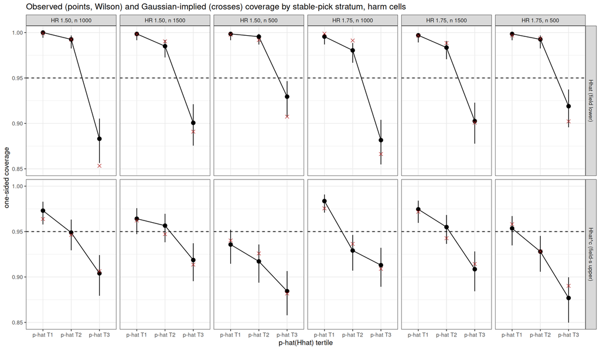

```r
TT <- TERT[TERT$stratum != "all" & TERT$cell %in% harm_labs, ]
TT$tertile <- sub(" \\[.*", "", TT$stratum)
TP <- rbind(data.frame(cell = TT$cell, tertile = TT$tertile, block = "Hhat (field lower)",     cov = TT$cov_field_H,   lo = TT$wH_lo, hi = TT$wH_hi, implied = TT$gauss_H),
            data.frame(cell = TT$cell, tertile = TT$tertile, block = "Hhat^c (field-s upper)", cov = TT$cov_field_s_C, lo = TT$wC_lo, hi = TT$wC_hi, implied = TT$gauss_C))
ggplot(TP, aes(tertile, cov, group = 1)) + geom_hline(yintercept = 0.95, linetype = 2) +
  geom_pointrange(aes(ymin = lo, ymax = hi)) + geom_line() +
  geom_point(aes(y = implied), shape = 4, colour = "firebrick", size = 2) +
  facet_grid(block ~ cell) + labs(x = "p-hat(Hhat) tertile", y = "one-sided coverage",
       title = "Observed (points, Wilson) and Gaussian-implied (crosses) coverage by stable-pick stratum, harm cells") +
  theme_bw(base_size = 10)
```

# 5 Identification versus n

```r
IDENT <- do.call(rbind, lapply(labs, function(k) {
  r <- B[[k]]$results; d <- r[r$detected %in% 1L, , drop = FALSE]; tr <- B[[k]]$truth
  rat <- d$n_harm / d$n_true
  onv_H  <- mean(log(d$nv_H_est)  - log(d$betaHhat_H))
  onv_Hc <- mean(log(d$nv_Hc_est) - log(d$betaHhat_Hc))
  sdm_H  <- sd(log(d$nv_H_est));  sde_H  <- sd(log(d$nv_H_est)  - log(d$betaHhat_H))
  sdm_Hc <- sd(log(d$nv_Hc_est)); sde_Hc <- sd(log(d$nv_Hc_est) - log(d$betaHhat_Hc))
  data.frame(cell = k, n = NN[[k]], HR = HR[[k]], arm = ARM[[k]],
             detection = mean(r$detected %in% 1L), n_det = nrow(d),
             sens = mean(d$sens), spec = mean(d$spec), ppv = mean(d$ppv), npv = mean(d$npv),
             Hhat_over_H_med = median(rat), Hhat_over_H_q90 = unname(quantile(rat, .9)),
             absH_mean = mean(d$n_sel), absHtrue_mean = mean(d$n_true),
             beta_H_mean = mean(d$betaHhat_H), planted_H = unname(tr$marg_H),
             beta_Hc_mean = mean(d$betaHhat_Hc), planted_Hc = unname(tr$marg_Hc),
             naive_opt_H_marg = onv_H / sdm_H, naive_opt_H_err = onv_H / sde_H,
             naive_opt_Hc_marg = onv_Hc / sdm_Hc, naive_opt_Hc_err = onv_Hc / sde_Hc,
             p_hat_mean = mean(d$p_hat_H[is.finite(d$p_hat_H)]),
             K_mean = mean(d$n_family), qual_mean = mean(d$n_cons_qual)) }))
IDENT <- IDENT[order(IDENT$arm, IDENT$HR, IDENT$n), ]
kbl(IDENT, digits = 3, booktabs = TRUE, row.names = FALSE,
    caption = "Identification against n: detection; sens / spec / PPV / NPV; |Hhat|/|H| median and q90; the realized beta(Hhat) and beta(Hhat^c) against the planted marginal Cox targets; the naive optimism in marginal-SD and error-SD units on both blocks; mean p-hat(Hhat); family size K and the consistency-qualifying count.") |>
  kable_styling(font_size = 9)
```

Identification against n: detection; sens / spec / PPV / NPV; |Hhat|/|H| median and q90; the realized beta(Hhat) and beta(Hhat^c) against the planted marginal Cox targets; the naive optimism in marginal-SD and error-SD units on both blocks; mean p-hat(Hhat); family size K and the consistency-qualifying count.

| cell | n | HR | arm | detection | n_det | sens | spec | ppv | npv | Hhat_over_H_med | Hhat_over_H_q90 | absH_mean | absHtrue_mean | beta_H_mean | planted_H | beta_Hc_mean | planted_Hc | naive_opt_H_marg | naive_opt_H_err | naive_opt_Hc_marg | naive_opt_Hc_err | p_hat_mean | K_mean | qual_mean |
| --- | --- | --- | --- | --- | --- | --- | --- | --- | --- | --- | --- | --- | --- | --- | --- | --- | --- | --- | --- | --- | --- | --- | --- | --- |
| HR 1.50, n 500 | 500 | 1.50 | harm | 1.000 | 1999 | 0.590 | 0.893 | 0.706 | 0.837 | 0.793 | 1.179 | 127.123 | 152.947 | 1.256 | 1.499 | 0.808 | 0.721 | 1.809 | 1.530 | -0.789 | -0.862 | 0.103 | 1228.432 | 202.425 |
| HR 1.50, n 1000 | 1000 | 1.50 | harm | 1.000 | 2000 | 0.708 | 0.928 | 0.804 | 0.887 | 0.912 | 1.221 | 266.807 | 306.254 | 1.351 | 1.499 | 0.774 | 0.721 | 1.171 | 0.982 | -0.537 | -0.642 | 0.117 | 1323.515 | 303.526 |
| HR 1.50, n 1500 | 1500 | 1.50 | harm | 1.000 | 2000 | 0.839 | 0.926 | 0.837 | 0.937 | 1.062 | 1.325 | 463.084 | 459.686 | 1.379 | 1.499 | 0.742 | 0.721 | 0.692 | 0.640 | -0.435 | -0.530 | 0.122 | 1324.172 | 361.036 |
| HR 1.75, n 500 | 500 | 1.75 | harm | 1.000 | 1999 | 0.660 | 0.919 | 0.779 | 0.866 | 0.821 | 1.163 | 128.930 | 152.947 | 1.515 | 1.746 | 0.808 | 0.721 | 1.481 | 1.241 | -0.631 | -0.708 | 0.119 | 1228.432 | 276.858 |
| HR 1.75, n 1000 | 1000 | 1.75 | harm | 1.000 | 2000 | 0.769 | 0.948 | 0.860 | 0.911 | 0.950 | 1.197 | 271.735 | 306.254 | 1.624 | 1.746 | 0.771 | 0.721 | 0.901 | 0.774 | -0.385 | -0.482 | 0.144 | 1323.515 | 408.057 |
| HR 1.75, n 1500 | 1500 | 1.75 | harm | 1.000 | 2000 | 0.874 | 0.947 | 0.883 | 0.951 | 1.055 | 1.258 | 457.266 | 459.686 | 1.645 | 1.746 | 0.740 | 0.721 | 0.510 | 0.483 | -0.321 | -0.406 | 0.168 | 1324.172 | 476.622 |
| HR 1.00, n 500 | 500 | 1.00 | null | 0.920 | 1841 | 0.387 | 0.828 | 0.494 | 0.757 | 0.730 | 1.140 | 118.987 | 153.067 | 0.829 | 1.000 | 0.766 | 0.721 | 3.172 | 2.812 | -1.074 | -1.107 | 0.086 | 1228.636 | 52.381 |
| HR 1.00, n 1000 | 1000 | 1.00 | null | 0.955 | 1909 | 0.460 | 0.853 | 0.565 | 0.788 | 0.740 | 1.221 | 243.091 | 306.233 | 0.852 | 1.000 | 0.757 | 0.721 | 2.390 | 1.996 | -0.993 | -1.047 | 0.081 | 1323.415 | 59.269 |
| HR 1.00, n 1500 | 1500 | 1.00 | null | 0.959 | 1918 | 0.581 | 0.843 | 0.618 | 0.829 | 0.914 | 1.391 | 430.637 | 459.751 | 0.869 | 1.000 | 0.746 | 0.721 | 1.981 | 1.627 | -1.051 | -1.106 | 0.067 | 1324.074 | 59.801 |

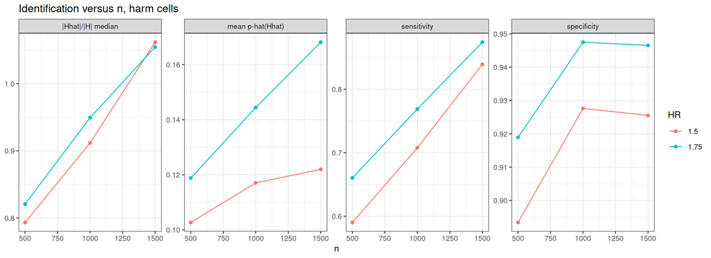

```r
ID <- IDENT[IDENT$arm == "harm", ]
IP <- rbind(data.frame(n = ID$n, HR = factor(ID$HR), what = "sensitivity", v = ID$sens),
            data.frame(n = ID$n, HR = factor(ID$HR), what = "specificity", v = ID$spec),
            data.frame(n = ID$n, HR = factor(ID$HR), what = "|Hhat|/|H| median", v = ID$Hhat_over_H_med),
            data.frame(n = ID$n, HR = factor(ID$HR), what = "mean p-hat(Hhat)", v = ID$p_hat_mean))
ggplot(IP, aes(n, v, colour = HR, group = HR)) + geom_point() + geom_line() +
  facet_wrap(~ what, scales = "free_y", nrow = 1) + labs(x = "n", y = NULL, title = "Identification versus n, harm cells") +
  theme_bw(base_size = 10)
```

# 6 The null cells (HR 1.00)

At the null there is no planted harm effect to find, so nothing here is scored against an acceptance criterion. What is recorded is the detection rate under the screen, and — among detections — where the two bounds sit relative to the realized β(Ĥ) and β(Ĥᶜ) of whatever region the search returned.

```r
if (length(null_labs)) {
  NUL <- do.call(rbind, lapply(null_labs, function(k) {
    r <- B[[k]]$results; d <- prep(r)
    data.frame(cell = k, n = NN[[k]], detection = mean(r$detected %in% 1L), n_eval = nrow(d),
               beta_H_mean = mean(d$betaHhat_H), beta_Hc_mean = mean(d$betaHhat_Hc),
               harm_field_1s = mean(d$betaHhat_H >= d$fld_H_lo1s),
               comp_field_s_1s = mean(d$betaHhat_Hc <= d$fld_Hc_up1s_s),
               comp_field_1s = mean(d$betaHhat_Hc <= d$fld_Hc_up1s),
               H_lower_mean = mean(d$fld_H_lo1s),
               share_H_lower_ge_100 = mean(d$fld_H_lo1s >= 1.00),
               share_H_lower_ge_085 = mean(d$fld_H_lo1s >= 0.85),
               Hc_upper_mean = mean(d$fld_Hc_up1s_s),
               share_Hc_upper_lt_085 = mean(d$fld_Hc_up1s_s < 0.85),
               share_Hc_upper_lt_080 = mean(d$fld_Hc_up1s_s < 0.80)) }))
  kbl(NUL, digits = 4, booktabs = TRUE, row.names = FALSE,
      caption = "Null cells: detection under the screen; among detections the realized beta on both blocks, the one-sided rates of each bound against its own block's realized beta, and the bounds by location (share of the harm lower bound at or above 1.00 and 0.85; share of the complement upper bound below 0.85 and 0.80).") |>
    kable_styling(font_size = 10)
} else cat("\nNo null cell on disk.\n")
```

Null cells: detection under the screen; among detections the realized beta on both blocks, the one-sided rates of each bound against its own block's realized beta, and the bounds by location (share of the harm lower bound at or above 1.00 and 0.85; share of the complement upper bound below 0.85 and 0.80).

| cell | n | detection | n_eval | beta_H_mean | beta_Hc_mean | harm_field_1s | comp_field_s_1s | comp_field_1s | H_lower_mean | share_H_lower_ge_100 | share_H_lower_ge_085 | Hc_upper_mean | share_Hc_upper_lt_085 | share_Hc_upper_lt_080 |
| --- | --- | --- | --- | --- | --- | --- | --- | --- | --- | --- | --- | --- | --- | --- |
| HR 1.00, n 500 | 500 | 0.9205 | 1841 | 0.8290 | 0.7656 | 0.9734 | 0.9115 | 0.9044 | 0.4916 | 0.0060 | 0.0250 | 0.9355 | 0.2618 | 0.1472 |
| HR 1.00, n 1000 | 1000 | 0.9545 | 1909 | 0.8520 | 0.7568 | 0.9560 | 0.9277 | 0.9183 | 0.5788 | 0.0105 | 0.0414 | 0.8777 | 0.3971 | 0.1875 |
| HR 1.00, n 1500 | 1500 | 0.9590 | 1918 | 0.8694 | 0.7465 | 0.9666 | 0.9270 | 0.9135 | 0.6269 | 0.0094 | 0.0360 | 0.8445 | 0.5375 | 0.2701 |

# 7 Acceptance criteria, evaluated per cell

Pre-registered in `TASK_cert20_2026-09-08`: harm field one-sided lower ≥ 0.94 **with Wilson support** at every harm cell; field-s complement one-sided upper ≥ 0.90 (n 500), ≥ 0.93 (n 1000), ≥ 0.94 (n 1500), Wilson-supported; IJ two-sided ≥ 0.93 everywhere; joint Bonferroni ≥ 0.93. “Wilson-supported” is read here as the Wilson **lower** limit reaching the bar — the strict reading; the point estimate is given beside it so the weaker reading is also visible. Null cells are recorded, not scored.

```r
bar_comp <- function(n) if (n <= 500L) 0.90 else if (n <= 1000L) 0.93 else 0.94
ACC <- do.call(rbind, lapply(labs, function(k) {
  v <- VSN[VSN$cell == k, ]
  rows <- list(
    list(crit = "harm field one-sided lower >= 0.94", bar = 0.94, p = v$harm_field,  lo = v$harm_field_lo,  scored = ARM[[k]] == "harm"),
    list(crit = sprintf("complement field-s one-sided upper >= %.2f", bar_comp(NN[[k]])), bar = bar_comp(NN[[k]]), p = v$comp_field_s, lo = v$comp_field_s_lo, scored = ARM[[k]] == "harm"),
    list(crit = "IJ two-sided >= 0.93 (harm block)",       bar = 0.93, p = v$ij2_H,  lo = v$ij2_H_lo,  scored = ARM[[k]] == "harm"),
    list(crit = "IJ two-sided >= 0.93 (complement block)", bar = 0.93, p = v$ij2_Hc, lo = v$ij2_Hc_lo, scored = ARM[[k]] == "harm"),
    list(crit = "joint Bonferroni (joint_s) >= 0.93",      bar = 0.93, p = v$joint_s_bonf, lo = v$joint_s_bonf_lo, scored = ARM[[k]] == "harm"))
  do.call(rbind, lapply(rows, function(x)
    data.frame(cell = k, n = NN[[k]], HR = HR[[k]], arm = ARM[[k]], criterion = x$crit, bar = x$bar,
               observed = x$p, wilson_lo = x$lo,
               verdict = if (!x$scored) "not scored (null cell)" else if (x$lo >= x$bar) "met" else if (x$p >= x$bar) "met on the point estimate only" else "not met",
               stringsAsFactors = FALSE))) }))
ACC <- ACC[order(ACC$arm, ACC$HR, ACC$n), ]
kbl(ACC, digits = 4, booktabs = TRUE, row.names = FALSE,
    caption = "The pre-registered acceptance criteria, per cell, with the number: observed coverage, its Wilson lower limit, and the verdict on the strict (Wilson-supported) reading.") |>
  kable_styling(font_size = 9)
```

The pre-registered acceptance criteria, per cell, with the number: observed coverage, its Wilson lower limit, and the verdict on the strict (Wilson-supported) reading.

| cell | n | HR | arm | criterion | bar | observed | wilson_lo | verdict |
| --- | --- | --- | --- | --- | --- | --- | --- | --- |
| HR 1.50, n 500 | 500 | 1.50 | harm | harm field one-sided lower >= 0.94 | 0.94 | 0.9745 | 0.9666 | met |
| HR 1.50, n 500 | 500 | 1.50 | harm | complement field-s one-sided upper >= 0.90 | 0.90 | 0.9125 | 0.8993 | met on the point estimate only |
| HR 1.50, n 500 | 500 | 1.50 | harm | IJ two-sided >= 0.93 (harm block) | 0.93 | 0.9810 | 0.9740 | met |
| HR 1.50, n 500 | 500 | 1.50 | harm | IJ two-sided >= 0.93 (complement block) | 0.93 | 1.0000 | 0.9981 | met |
| HR 1.50, n 500 | 500 | 1.50 | harm | joint Bonferroni (joint_s) >= 0.93 | 0.93 | 0.9420 | 0.9308 | met |
| HR 1.50, n 1000 | 1000 | 1.50 | harm | harm field one-sided lower >= 0.94 | 0.94 | 0.9585 | 0.9488 | met |
| HR 1.50, n 1000 | 1000 | 1.50 | harm | complement field-s one-sided upper >= 0.93 | 0.93 | 0.9420 | 0.9309 | met |
| HR 1.50, n 1000 | 1000 | 1.50 | harm | IJ two-sided >= 0.93 (harm block) | 0.93 | 0.9710 | 0.9627 | met |
| HR 1.50, n 1000 | 1000 | 1.50 | harm | IJ two-sided >= 0.93 (complement block) | 0.93 | 1.0000 | 0.9981 | met |
| HR 1.50, n 1000 | 1000 | 1.50 | harm | joint Bonferroni (joint_s) >= 0.93 | 0.93 | 0.9500 | 0.9396 | met |
| HR 1.50, n 1500 | 1500 | 1.50 | harm | harm field one-sided lower >= 0.94 | 0.94 | 0.9615 | 0.9521 | met |
| HR 1.50, n 1500 | 1500 | 1.50 | harm | complement field-s one-sided upper >= 0.94 | 0.94 | 0.9465 | 0.9358 | met on the point estimate only |
| HR 1.50, n 1500 | 1500 | 1.50 | harm | IJ two-sided >= 0.93 (harm block) | 0.93 | 0.9755 | 0.9678 | met |
| HR 1.50, n 1500 | 1500 | 1.50 | harm | IJ two-sided >= 0.93 (complement block) | 0.93 | 0.9995 | 0.9972 | met |
| HR 1.50, n 1500 | 1500 | 1.50 | harm | joint Bonferroni (joint_s) >= 0.93 | 0.93 | 0.9505 | 0.9401 | met |
| HR 1.75, n 500 | 500 | 1.75 | harm | harm field one-sided lower >= 0.94 | 0.94 | 0.9700 | 0.9616 | met |
| HR 1.75, n 500 | 500 | 1.75 | harm | complement field-s one-sided upper >= 0.90 | 0.90 | 0.9195 | 0.9067 | met |
| HR 1.75, n 500 | 500 | 1.75 | harm | IJ two-sided >= 0.93 (harm block) | 0.93 | 0.9720 | 0.9638 | met |
| HR 1.75, n 500 | 500 | 1.75 | harm | IJ two-sided >= 0.93 (complement block) | 0.93 | 0.9995 | 0.9972 | met |
| HR 1.75, n 500 | 500 | 1.75 | harm | joint Bonferroni (joint_s) >= 0.93 | 0.93 | 0.9395 | 0.9281 | met on the point estimate only |
| HR 1.75, n 1000 | 1000 | 1.75 | harm | harm field one-sided lower >= 0.94 | 0.94 | 0.9525 | 0.9423 | met |
| HR 1.75, n 1000 | 1000 | 1.75 | harm | complement field-s one-sided upper >= 0.93 | 0.93 | 0.9420 | 0.9309 | met |
| HR 1.75, n 1000 | 1000 | 1.75 | harm | IJ two-sided >= 0.93 (harm block) | 0.93 | 0.9740 | 0.9661 | met |
| HR 1.75, n 1000 | 1000 | 1.75 | harm | IJ two-sided >= 0.93 (complement block) | 0.93 | 1.0000 | 0.9981 | met |
| HR 1.75, n 1000 | 1000 | 1.75 | harm | joint Bonferroni (joint_s) >= 0.93 | 0.93 | 0.9485 | 0.9379 | met |
| HR 1.75, n 1500 | 1500 | 1.75 | harm | harm field one-sided lower >= 0.94 | 0.94 | 0.9610 | 0.9516 | met |
| HR 1.75, n 1500 | 1500 | 1.75 | harm | complement field-s one-sided upper >= 0.94 | 0.94 | 0.9460 | 0.9352 | met on the point estimate only |
| HR 1.75, n 1500 | 1500 | 1.75 | harm | IJ two-sided >= 0.93 (harm block) | 0.93 | 0.9805 | 0.9735 | met |
| HR 1.75, n 1500 | 1500 | 1.75 | harm | IJ two-sided >= 0.93 (complement block) | 0.93 | 0.9995 | 0.9972 | met |
| HR 1.75, n 1500 | 1500 | 1.75 | harm | joint Bonferroni (joint_s) >= 0.93 | 0.93 | 0.9490 | 0.9385 | met |
| HR 1.00, n 500 | 500 | 1.00 | null | harm field one-sided lower >= 0.94 | 0.94 | 0.9734 | 0.9650 | not scored (null cell) |
| HR 1.00, n 500 | 500 | 1.00 | null | complement field-s one-sided upper >= 0.90 | 0.90 | 0.9115 | 0.8976 | not scored (null cell) |
| HR 1.00, n 500 | 500 | 1.00 | null | IJ two-sided >= 0.93 (harm block) | 0.93 | 0.9946 | 0.9900 | not scored (null cell) |
| HR 1.00, n 500 | 500 | 1.00 | null | IJ two-sided >= 0.93 (complement block) | 0.93 | 0.9989 | 0.9960 | not scored (null cell) |
| HR 1.00, n 500 | 500 | 1.00 | null | joint Bonferroni (joint_s) >= 0.93 | 0.93 | 0.9430 | 0.9314 | not scored (null cell) |
| HR 1.00, n 1000 | 1000 | 1.00 | null | harm field one-sided lower >= 0.94 | 0.94 | 0.9560 | 0.9458 | not scored (null cell) |
| HR 1.00, n 1000 | 1000 | 1.00 | null | complement field-s one-sided upper >= 0.93 | 0.93 | 0.9277 | 0.9152 | not scored (null cell) |
| HR 1.00, n 1000 | 1000 | 1.00 | null | IJ two-sided >= 0.93 (harm block) | 0.93 | 0.9948 | 0.9904 | not scored (null cell) |
| HR 1.00, n 1000 | 1000 | 1.00 | null | IJ two-sided >= 0.93 (complement block) | 0.93 | 1.0000 | 0.9980 | not scored (null cell) |
| HR 1.00, n 1000 | 1000 | 1.00 | null | joint Bonferroni (joint_s) >= 0.93 | 0.93 | 0.9371 | 0.9253 | not scored (null cell) |
| HR 1.00, n 1500 | 1500 | 1.00 | null | harm field one-sided lower >= 0.94 | 0.94 | 0.9666 | 0.9576 | not scored (null cell) |
| HR 1.00, n 1500 | 1500 | 1.00 | null | complement field-s one-sided upper >= 0.94 | 0.94 | 0.9270 | 0.9145 | not scored (null cell) |
| HR 1.00, n 1500 | 1500 | 1.00 | null | IJ two-sided >= 0.93 (harm block) | 0.93 | 0.9964 | 0.9925 | not scored (null cell) |
| HR 1.00, n 1500 | 1500 | 1.00 | null | IJ two-sided >= 0.93 (complement block) | 0.93 | 1.0000 | 0.9980 | not scored (null cell) |
| HR 1.00, n 1500 | 1500 | 1.00 | null | joint Bonferroni (joint_s) >= 0.93 | 0.93 | 0.9526 | 0.9421 | not scored (null cell) |

# 8 Numbers for the record

**Coverage versus n (harm cells; field lower / field-s upper / IJ two-sided H / IJ two-sided Hc / joint_s Bonferroni):**

- HR 1.50, n 500 (n_eval 1999): harm field 0.974 [0.967, 0.981]; complement field-s 0.912 [0.899, 0.924] (field 0.897); IJ two-sided 0.981 / 1.000; joint_s Bonferroni 0.942 [0.931, 0.951]
- HR 1.50, n 1000 (n_eval 2000): harm field 0.959 [0.949, 0.966]; complement field-s 0.942 [0.931, 0.951] (field 0.930); IJ two-sided 0.971 / 1.000; joint_s Bonferroni 0.950 [0.940, 0.959]
- HR 1.50, n 1500 (n_eval 2000): harm field 0.962 [0.952, 0.969]; complement field-s 0.947 [0.936, 0.956] (field 0.939); IJ two-sided 0.976 / 1.000; joint_s Bonferroni 0.951 [0.940, 0.959]
- HR 1.75, n 500 (n_eval 1999): harm field 0.970 [0.962, 0.977]; complement field-s 0.919 [0.907, 0.931] (field 0.912); IJ two-sided 0.972 / 0.999; joint_s Bonferroni 0.939 [0.928, 0.949]
- HR 1.75, n 1000 (n_eval 2000): harm field 0.953 [0.942, 0.961]; complement field-s 0.942 [0.931, 0.951] (field 0.936); IJ two-sided 0.974 / 1.000; joint_s Bonferroni 0.949 [0.938, 0.957]
- HR 1.75, n 1500 (n_eval 2000): harm field 0.961 [0.952, 0.969]; complement field-s 0.946 [0.935, 0.955] (field 0.941); IJ two-sided 0.981 / 1.000; joint_s Bonferroni 0.949 [0.938, 0.958]

**The stable-pick stratum (p-hat tertiles T1/T2/T3, observed -> Gaussian-implied):**

- HR 1.50, n 500: harm field 0.999 / 0.995 / 0.929 (implied 0.998 / 0.992 / 0.907); complement field-s 0.936 / 0.917 / 0.884 (implied 0.940 / 0.926 / 0.882); mean ef_s -0.0099 / -0.0272 / -0.0555
- HR 1.50, n 1000: harm field 1.000 / 0.992 / 0.883 (implied 0.999 / 0.992 / 0.853); complement field-s 0.973 / 0.949 / 0.904 (implied 0.964 / 0.946 / 0.906); mean ef_s +0.0212 / -0.0032 / -0.0383
- HR 1.50, n 1500: harm field 0.999 / 0.985 / 0.901 (implied 0.998 / 0.990 / 0.891); complement field-s 0.964 / 0.957 / 0.919 (implied 0.962 / 0.947 / 0.914); mean ef_s +0.0185 / -0.0044 / -0.0312
- HR 1.75, n 500: harm field 0.999 / 0.992 / 0.919 (implied 0.997 / 0.993 / 0.902); complement field-s 0.954 / 0.928 / 0.877 (implied 0.958 / 0.928 / 0.890); mean ef_s +0.0162 / -0.0225 / -0.0518
- HR 1.75, n 1000: harm field 0.996 / 0.980 / 0.882 (implied 0.999 / 0.991 / 0.866); complement field-s 0.984 / 0.929 / 0.913 (implied 0.976 / 0.936 / 0.909); mean ef_s +0.0291 / -0.0035 / -0.0332
- HR 1.75, n 1500: harm field 0.997 / 0.983 / 0.903 (implied 0.996 / 0.988 / 0.901); complement field-s 0.975 / 0.955 / 0.909 (implied 0.972 / 0.943 / 0.914); mean ef_s +0.0215 / -0.0080 / -0.0297
- HR 1.00, n 500: harm field 0.998 / 0.995 / 0.927 (implied 0.998 / 0.997 / 0.901); complement field-s 0.948 / 0.915 / 0.871 (implied 0.946 / 0.928 / 0.872); mean ef_s -0.0170 / -0.0360 / -0.0691
- HR 1.00, n 1000: harm field 1.000 / 0.997 / 0.871 (implied 1.000 / 0.995 / 0.826); complement field-s 0.948 / 0.945 / 0.890 (implied 0.954 / 0.938 / 0.883); mean ef_s -0.0030 / -0.0178 / -0.0423
- HR 1.00, n 1500: harm field 1.000 / 0.997 / 0.903 (implied 1.000 / 0.996 / 0.867); complement field-s 0.959 / 0.930 / 0.892 (implied 0.957 / 0.936 / 0.889); mean ef_s -0.0024 / -0.0178 / -0.0369

**Identification versus n:**

- HR 1.50, n 500: detection 1.000; sens 0.590 spec 0.893 ppv 0.706 npv 0.837; |Hhat|/|H| median 0.793 q90 1.179; beta(Hhat) 1.256 vs planted 1.499; beta(Hhat^c) 0.808 vs planted 0.721; naive optimism 1.809 marginal-SD / 1.530 error-SD (H), -0.789 / -0.862 (Hc); mean p-hat 0.103
- HR 1.50, n 1000: detection 1.000; sens 0.708 spec 0.928 ppv 0.804 npv 0.887; |Hhat|/|H| median 0.912 q90 1.221; beta(Hhat) 1.351 vs planted 1.499; beta(Hhat^c) 0.774 vs planted 0.721; naive optimism 1.171 marginal-SD / 0.982 error-SD (H), -0.537 / -0.642 (Hc); mean p-hat 0.117
- HR 1.50, n 1500: detection 1.000; sens 0.839 spec 0.926 ppv 0.837 npv 0.937; |Hhat|/|H| median 1.062 q90 1.325; beta(Hhat) 1.379 vs planted 1.499; beta(Hhat^c) 0.742 vs planted 0.721; naive optimism 0.692 marginal-SD / 0.640 error-SD (H), -0.435 / -0.530 (Hc); mean p-hat 0.122
- HR 1.75, n 500: detection 1.000; sens 0.660 spec 0.919 ppv 0.779 npv 0.866; |Hhat|/|H| median 0.821 q90 1.163; beta(Hhat) 1.515 vs planted 1.746; beta(Hhat^c) 0.808 vs planted 0.721; naive optimism 1.481 marginal-SD / 1.241 error-SD (H), -0.631 / -0.708 (Hc); mean p-hat 0.119
- HR 1.75, n 1000: detection 1.000; sens 0.769 spec 0.948 ppv 0.860 npv 0.911; |Hhat|/|H| median 0.950 q90 1.197; beta(Hhat) 1.624 vs planted 1.746; beta(Hhat^c) 0.771 vs planted 0.721; naive optimism 0.901 marginal-SD / 0.774 error-SD (H), -0.385 / -0.482 (Hc); mean p-hat 0.144
- HR 1.75, n 1500: detection 1.000; sens 0.874 spec 0.947 ppv 0.883 npv 0.951; |Hhat|/|H| median 1.055 q90 1.258; beta(Hhat) 1.645 vs planted 1.746; beta(Hhat^c) 0.740 vs planted 0.721; naive optimism 0.510 marginal-SD / 0.483 error-SD (H), -0.321 / -0.406 (Hc); mean p-hat 0.168
- HR 1.00, n 500: detection 0.920; sens 0.387 spec 0.828 ppv 0.494 npv 0.757; |Hhat|/|H| median 0.730 q90 1.140; beta(Hhat) 0.829 vs planted 1.000; beta(Hhat^c) 0.766 vs planted 0.721; naive optimism 3.172 marginal-SD / 2.812 error-SD (H), -1.074 / -1.107 (Hc); mean p-hat 0.086
- HR 1.00, n 1000: detection 0.955; sens 0.460 spec 0.853 ppv 0.565 npv 0.788; |Hhat|/|H| median 0.740 q90 1.221; beta(Hhat) 0.852 vs planted 1.000; beta(Hhat^c) 0.757 vs planted 0.721; naive optimism 2.390 marginal-SD / 1.996 error-SD (H), -0.993 / -1.047 (Hc); mean p-hat 0.081
- HR 1.00, n 1500: detection 0.959; sens 0.581 spec 0.843 ppv 0.618 npv 0.829; |Hhat|/|H| median 0.914 q90 1.391; beta(Hhat) 0.869 vs planted 1.000; beta(Hhat^c) 0.746 vs planted 0.721; naive optimism 1.981 marginal-SD / 1.627 error-SD (H), -1.051 / -1.106 (Hc); mean p-hat 0.067

**Acceptance criteria (strict, Wilson-supported):**

- HR 1.50, n 500: harm >= 0.94 = 0.974 [0.967] -> met; complement >= 0.90 = 0.912 [0.899] -> met on the point estimate only; IJ >= 0.93 (harm block) = 0.981 [0.974] -> met; IJ >= 0.93 (complement block) = 1.000 [0.998] -> met; joint >= 0.93 = 0.942 [0.931] -> met
- HR 1.50, n 1000: harm >= 0.94 = 0.959 [0.949] -> met; complement >= 0.93 = 0.942 [0.931] -> met; IJ >= 0.93 (harm block) = 0.971 [0.963] -> met; IJ >= 0.93 (complement block) = 1.000 [0.998] -> met; joint >= 0.93 = 0.950 [0.940] -> met
- HR 1.50, n 1500: harm >= 0.94 = 0.962 [0.952] -> met; complement >= 0.94 = 0.947 [0.936] -> met on the point estimate only; IJ >= 0.93 (harm block) = 0.976 [0.968] -> met; IJ >= 0.93 (complement block) = 1.000 [0.997] -> met; joint >= 0.93 = 0.951 [0.940] -> met
- HR 1.75, n 500: harm >= 0.94 = 0.970 [0.962] -> met; complement >= 0.90 = 0.919 [0.907] -> met; IJ >= 0.93 (harm block) = 0.972 [0.964] -> met; IJ >= 0.93 (complement block) = 0.999 [0.997] -> met; joint >= 0.93 = 0.939 [0.928] -> met on the point estimate only
- HR 1.75, n 1000: harm >= 0.94 = 0.953 [0.942] -> met; complement >= 0.93 = 0.942 [0.931] -> met; IJ >= 0.93 (harm block) = 0.974 [0.966] -> met; IJ >= 0.93 (complement block) = 1.000 [0.998] -> met; joint >= 0.93 = 0.949 [0.938] -> met
- HR 1.75, n 1500: harm >= 0.94 = 0.961 [0.952] -> met; complement >= 0.94 = 0.946 [0.935] -> met on the point estimate only; IJ >= 0.93 (harm block) = 0.981 [0.973] -> met; IJ >= 0.93 (complement block) = 1.000 [0.997] -> met; joint >= 0.93 = 0.949 [0.938] -> met

**Null cells (recorded, not scored):**

- HR 1.00, n 500: detection 0.920; beta(Hhat) 0.829, beta(Hhat^c) 0.766; harm lower one-sided rate 0.973, complement field-s upper 0.911; harm lower mean 0.492 (share >= 1.00 0.006); complement upper mean 0.935 (share < 0.80 0.147)
- HR 1.00, n 1000: detection 0.955; beta(Hhat) 0.852, beta(Hhat^c) 0.757; harm lower one-sided rate 0.956, complement field-s upper 0.928; harm lower mean 0.579 (share >= 1.00 0.010); complement upper mean 0.878 (share < 0.80 0.188)
- HR 1.00, n 1500: detection 0.959; beta(Hhat) 0.869, beta(Hhat^c) 0.746; harm lower one-sided rate 0.967, complement field-s upper 0.927; harm lower mean 0.627 (share >= 1.00 0.009); complement upper mean 0.845 (share < 0.80 0.270)